# SLEEP AND LIFESTYLE ANALYSIS

**Gender Column**

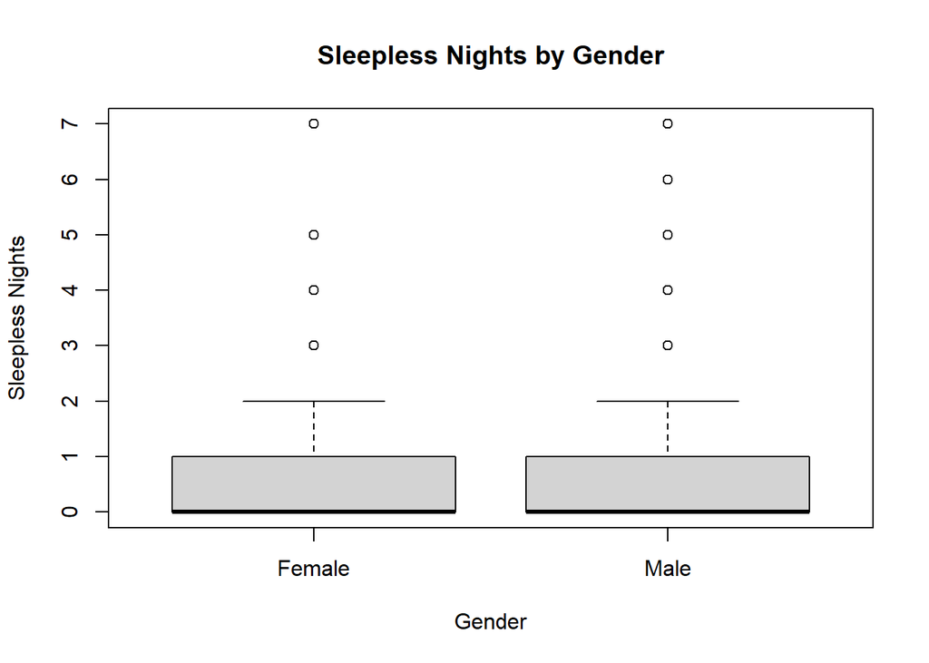

```r
boxplot(SleeplessNightsInAWeek ~ Gender, data = df,
        main = "Sleepless Nights by Gender",
        xlab = "Gender",
        ylab = "Sleepless Nights")
```

**Age column**

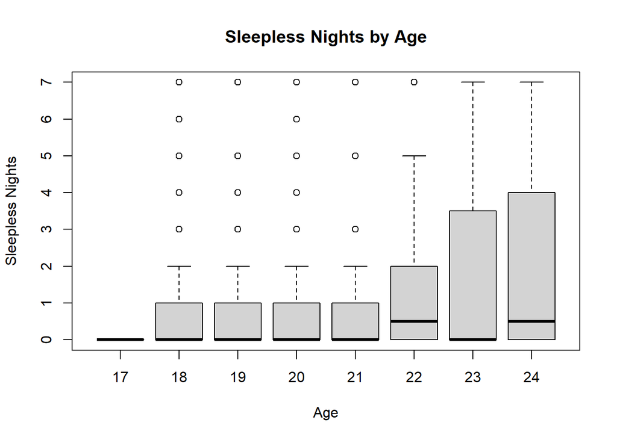

```r
boxplot(SleeplessNightsInAWeek ~ Age, data = df,
        main = "Sleepless Nights by Age",
        xlab = "Age",
        ylab = "Sleepless Nights")
```

**Branch Column**

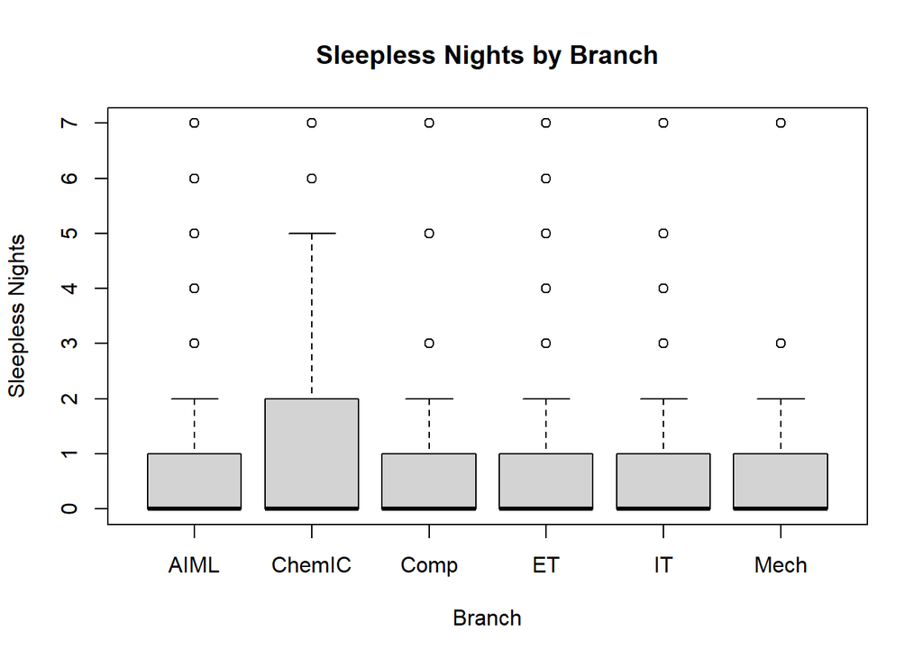

```r
boxplot(SleeplessNightsInAWeek ~ Branch, data = df,
        main = "Sleepless Nights by Branch",
        xlab = "Branch",
        ylab = "Sleepless Nights")
```

**Hours Of Sleep Column**

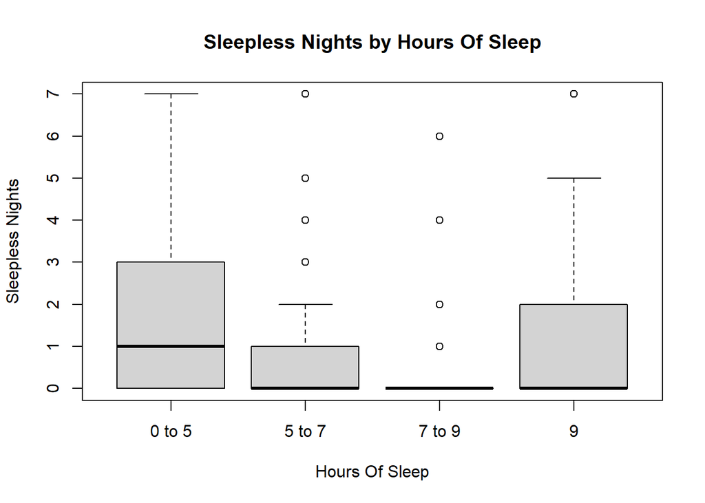

```r
boxplot(SleeplessNightsInAWeek ~ HoursOfSleep, data = df,
        main = "Sleepless Nights by Hours Of Sleep",
        xlab = "Hours Of Sleep",
        ylab = "Sleepless Nights")
```

**Quality of Sleep Column**

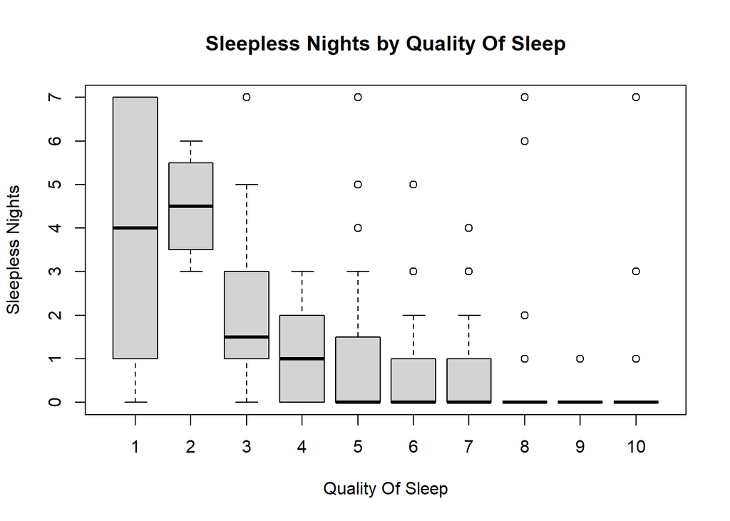

```r
boxplot(SleeplessNightsInAWeek ~ QualityOfSleep, data = df,
        main = "Sleepless Nights by Quality Of Sleep",
        xlab = "Quality Of Sleep",
        ylab = "Sleepless Nights")
```

**Naps In A Week Column**

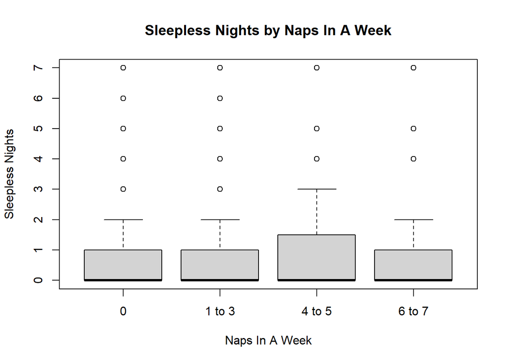

```r
boxplot(SleeplessNightsInAWeek ~ NapsInAweek, data = df,
        main = "Sleepless Nights by Naps In A Week",
        xlab = "Naps In A Week",
        ylab = "Sleepless Nights")
```

**Physical Activity Level**

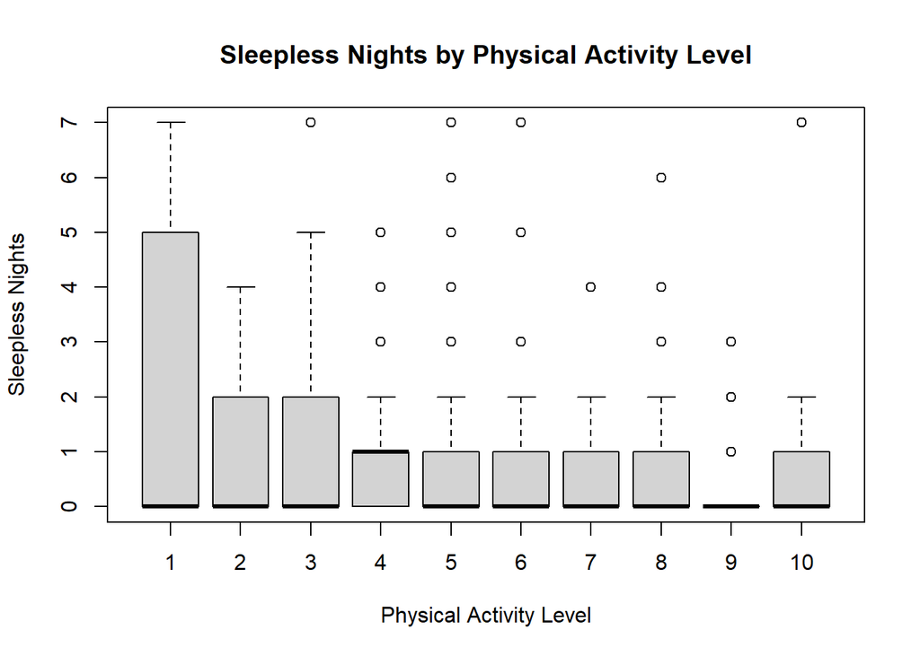

```r
boxplot(SleeplessNightsInAWeek ~ PhysicalActivityLevel, data = df,
        main = "Sleepless Nights by Physical Activity Level",
        xlab = "Physical Activity Level",
        ylab = "Sleepless Nights")
```

**Stress Level**

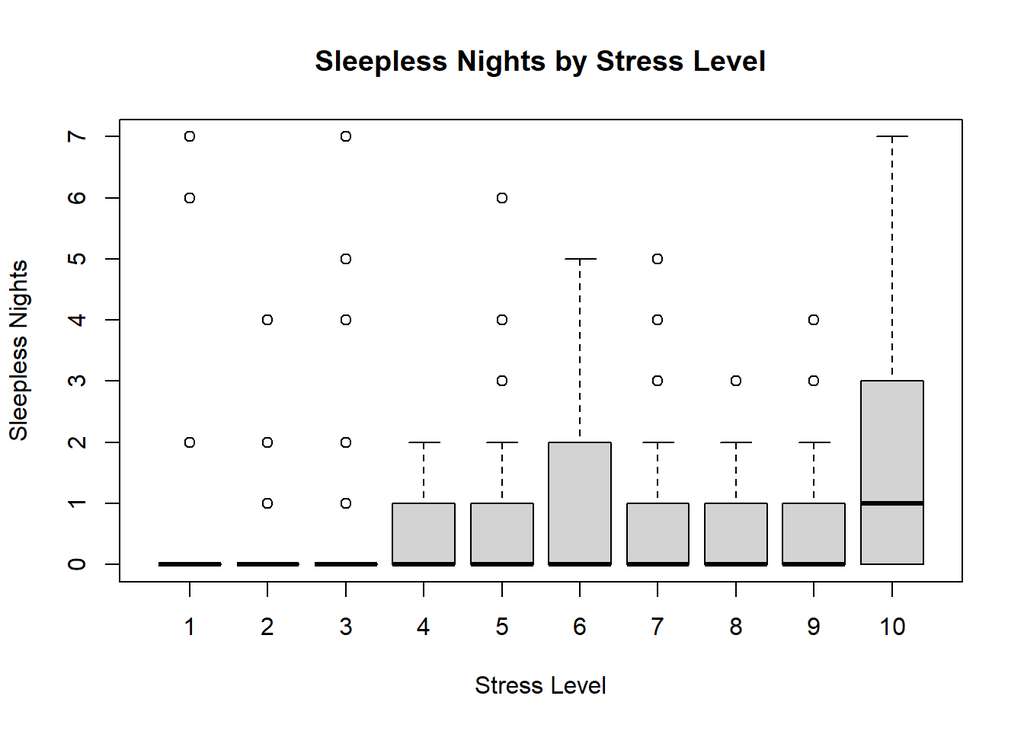

```r
boxplot(SleeplessNightsInAWeek ~ StressLevel, data = df,
        main = "Sleepless Nights by Stress Level",
        xlab = "Stress Level",
        ylab = "Sleepless Nights")
```

**Daily Steps**

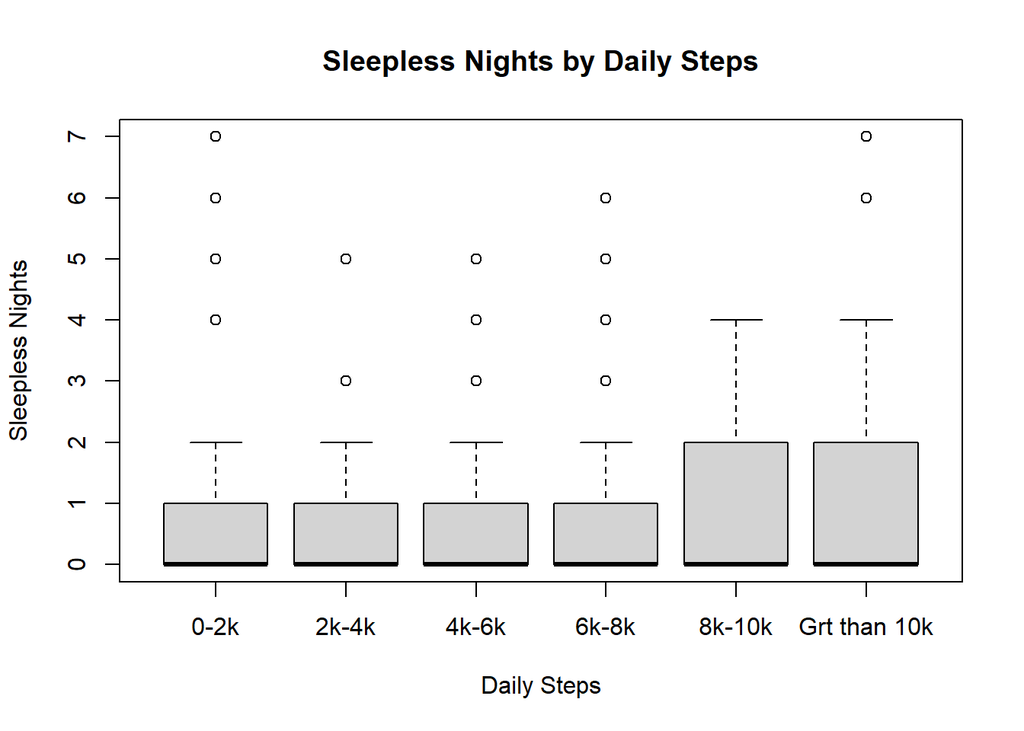

```r
boxplot(SleeplessNightsInAWeek ~ DailySteps, data = df,
        main = "Sleepless Nights by Daily Steps",
        xlab = "Daily Steps",
        ylab = "Sleepless Nights")
```

**Hours of EC Devices Before Sleep**

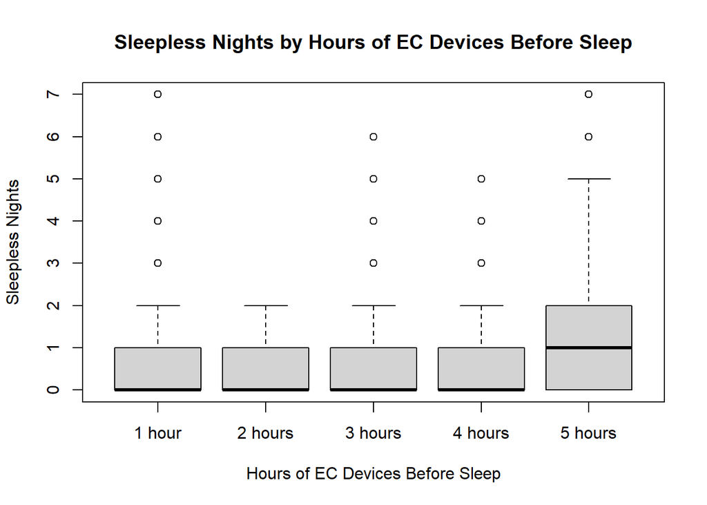

```r
boxplot(SleeplessNightsInAWeek ~ HoursOfECDevicesBeforeSleep, data = df,
        main = "Sleepless Nights by Hours of EC Devices Before Sleep",
        xlab = "Hours of EC Devices Before Sleep",
        ylab = "Sleepless Nights")
```

**Headache Frequency**

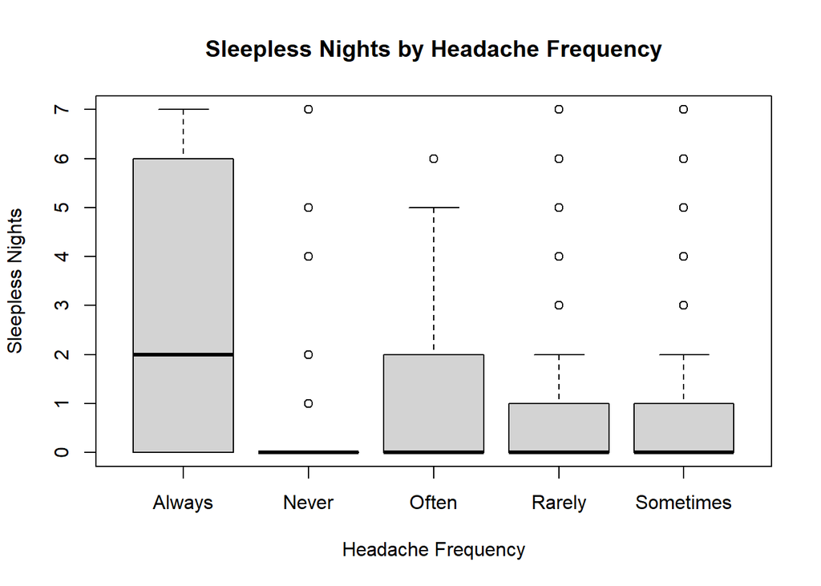

```r
boxplot(SleeplessNightsInAWeek ~ HeadacheFrequency, data = df,
        main = "Sleepless Nights by Headache Frequency",
        xlab = "Headache Frequency",
        ylab = "Sleepless Nights")
```

**Skip Breakfast**

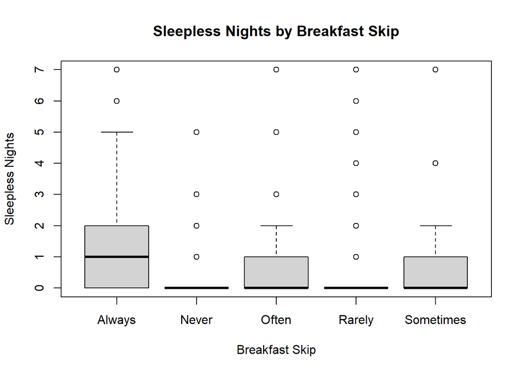

```r
boxplot(SleeplessNightsInAWeek ~ BreakfastSkip, data = df,
        main = "Sleepless Nights by Breakfast Skip",
        xlab = "Breakfast Skip",
        ylab = "Sleepless Nights")
```

**Dinner Time**

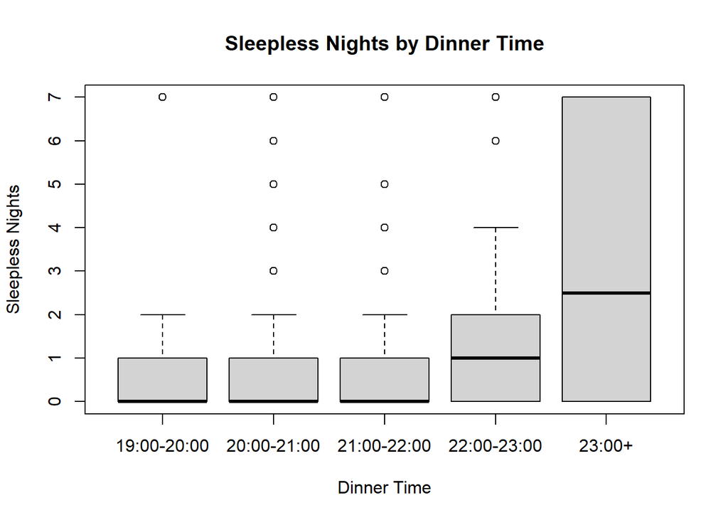

```r
boxplot(SleeplessNightsInAWeek ~ DinnerTime, data = df,
        main = "Sleepless Nights by Dinner Time",
        xlab = "Dinner Time",
        ylab = "Sleepless Nights")
```

**Correlation of Gender vs. Sleepless Nights**

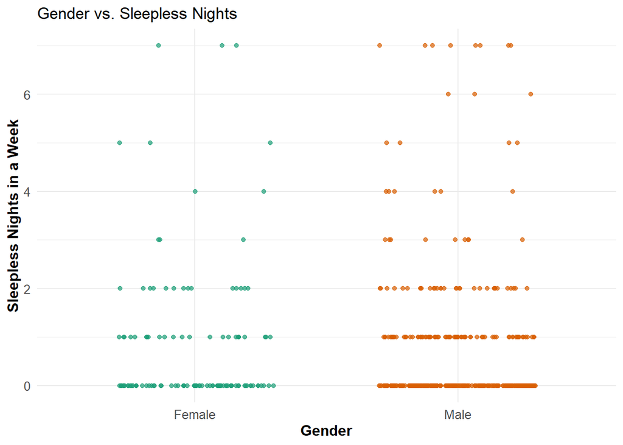

```r
ggplot(df, aes(x = Gender, y = SleeplessNightsInAWeek, color = Gender)) +
  geom_jitter(width = 0.3, height = 0, alpha = 0.7) +
  scale_color_brewer(palette = "Dark2") +
  labs(title = "Gender vs. Sleepless Nights",
       x = "Gender",
       y = "Sleepless Nights in a Week") +
  theme_minimal() +
  theme(legend.position = "none",
        axis.title = element_text(size = 12, face = "bold"),
        axis.text = element_text(size = 10))
```

**Correlation of Age vs. Sleepless Nights**

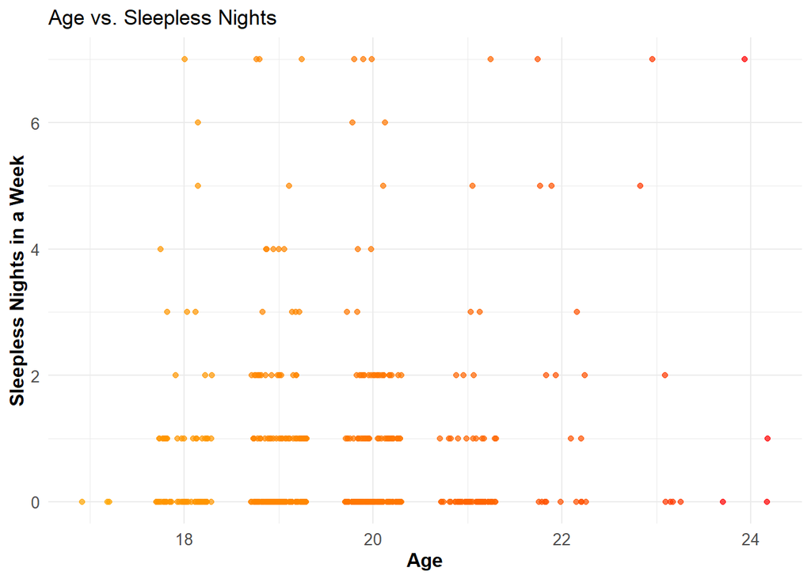

```r
ggplot(df, aes(x = Age, y = SleeplessNightsInAWeek, color = Age)) +
  geom_jitter(width = 0.3, height = 0, alpha = 0.7) +
  scale_color_gradient(low = "orange", high = "red") +
  labs(title = "Age vs. Sleepless Nights",
       x = "Age",
       y = "Sleepless Nights in a Week") +
  theme_minimal() +
  theme(legend.position = "none",
        axis.title = element_text(size = 12, face = "bold"),
        axis.text = element_text(size = 10))
```

**Correlation of Year vs. Sleepless Nights**

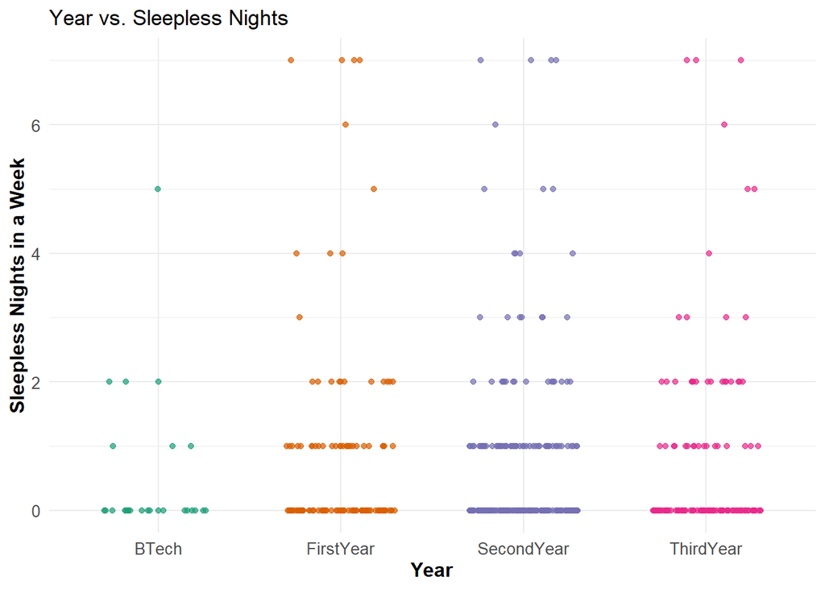

```r
ggplot(df, aes(x = Year, y = SleeplessNightsInAWeek, color = Year)) +
  geom_jitter(width = 0.3, height = 0, alpha = 0.7) +
  scale_color_brewer(palette = "Dark2") +
  labs(title = "Year vs. Sleepless Nights",
       x = "Year",
       y = "Sleepless Nights in a Week") +
  theme_minimal() +
  theme(legend.position = "none",
        axis.title = element_text(size = 12, face = "bold"),
        axis.text = element_text(size = 10))
```

**Correlation of Branch vs. Sleepless Nights**

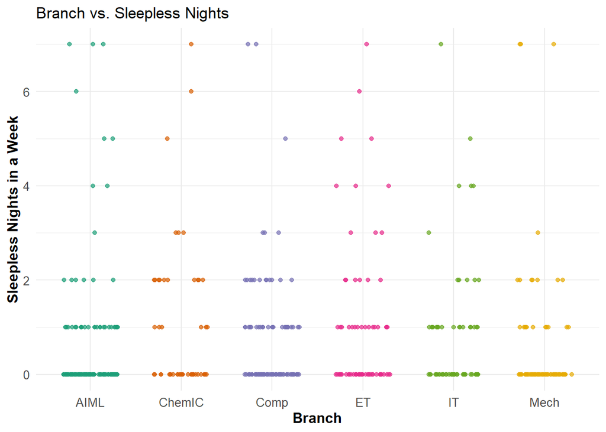

```r
ggplot(df, aes(x = Branch, y = SleeplessNightsInAWeek, color = Branch)) +
  geom_jitter(width = 0.3, height = 0, alpha = 0.7) +
  scale_color_brewer(palette = "Dark2") +
  labs(title = "Branch vs. Sleepless Nights",
       x = "Branch",
       y = "Sleepless Nights in a Week") +
  theme_minimal() +
  theme(legend.position = "none",
        axis.title = element_text(size = 12, face = "bold"),
        axis.text = element_text(size = 10))
```

**Correlation of Hours of Sleep vs. Sleepless Nights**

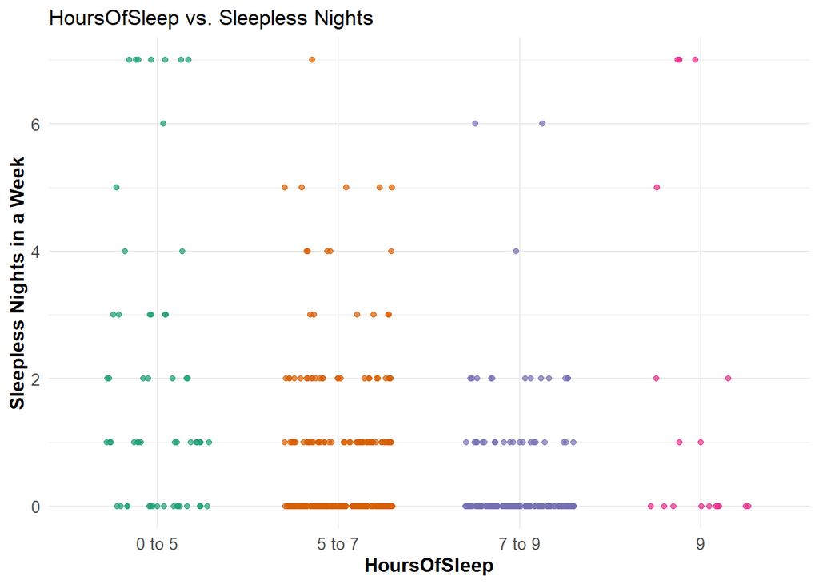

```r
ggplot(df, aes(x = HoursOfSleep, y = SleeplessNightsInAWeek, color = HoursOfSleep)) +
  geom_jitter(width = 0.3, height = 0, alpha = 0.7) +
  scale_color_brewer(palette = "Dark2") +
  labs(title = "HoursOfSleep vs. Sleepless Nights",
       x = "HoursOfSleep",
       y = "Sleepless Nights in a Week") +
  theme_minimal() +
  theme(legend.position = "none",
        axis.title = element_text(size = 12, face = "bold"),
        axis.text = element_text(size = 10))
```

**Correlation of Quality Of Sleep vs. Sleepless Nights**

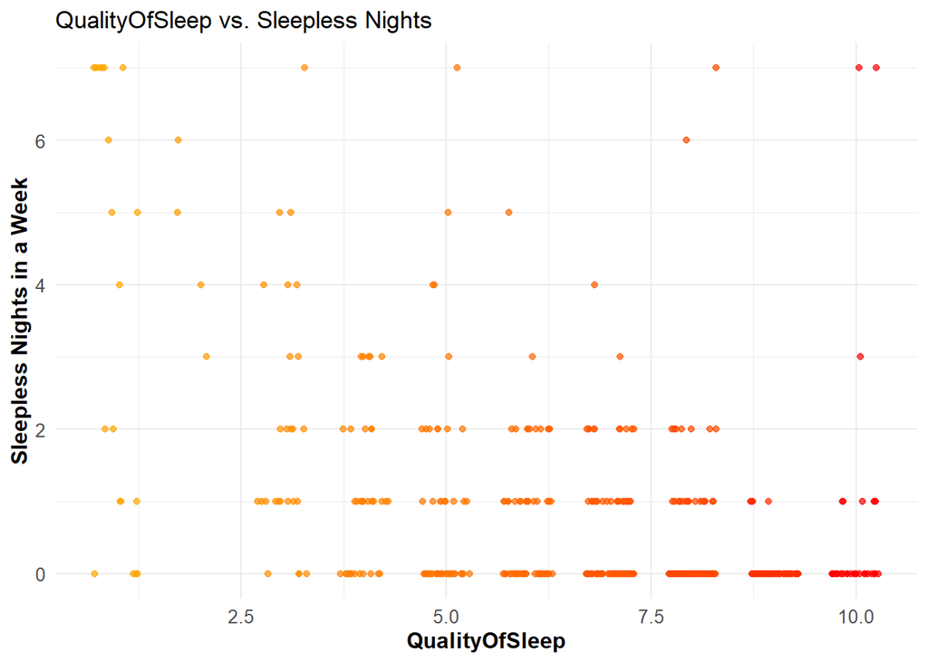

```r
ggplot(df, aes(x = QualityOfSleep, y = SleeplessNightsInAWeek, color = QualityOfSleep)) +
  geom_jitter(width = 0.3, height = 0, alpha = 0.7) +
  scale_color_gradient(low = "orange", high = "red") +
  labs(title = "QualityOfSleep vs. Sleepless Nights",
       x = "QualityOfSleep",
       y = "Sleepless Nights in a Week") +
  theme_minimal() +
  theme(legend.position = "none",
        axis.title = element_text(size = 12, face = "bold"),
        axis.text = element_text(size = 10))
```

**Correlation of Naps In A Week vs. Sleepless Nights**

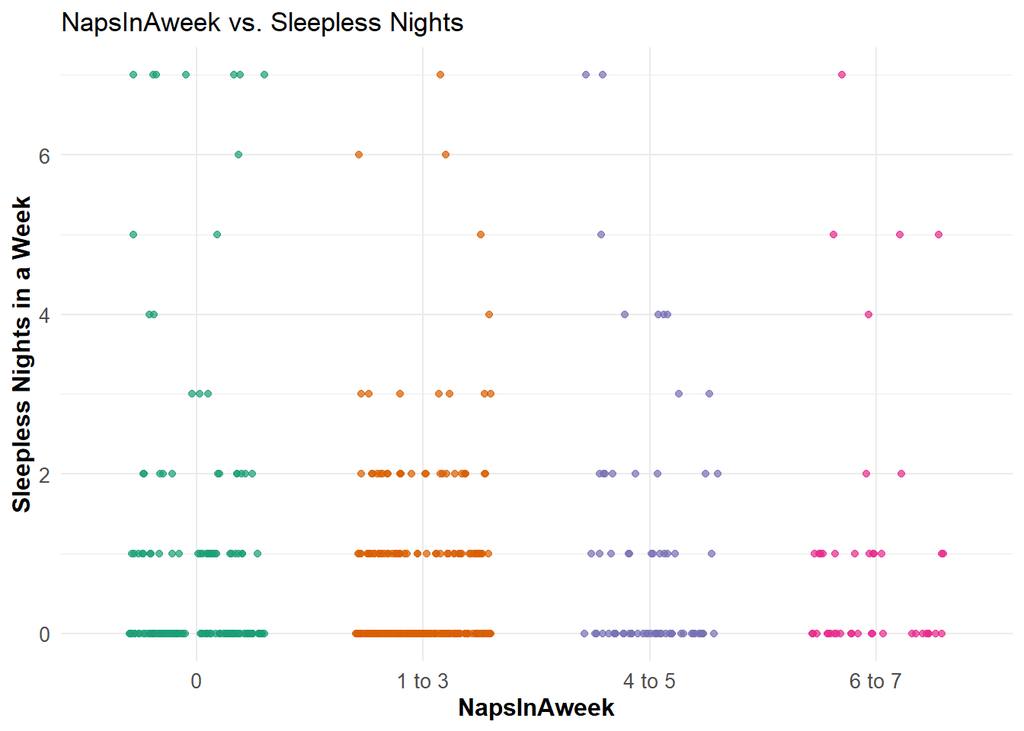

```r
ggplot(df, aes(x = NapsInAweek, y = SleeplessNightsInAWeek, color = NapsInAweek)) +
  geom_jitter(width = 0.3, height = 0, alpha = 0.7) +
  scale_color_brewer(palette = "Dark2") +
  labs(title = "NapsInAweek vs. Sleepless Nights",
       x = "NapsInAweek",
       y = "Sleepless Nights in a Week") +
  theme_minimal() +
  theme(legend.position = "none",
        axis.title = element_text(size = 12, face = "bold"),
        axis.text = element_text(size = 10))
```

**Correlation of Physical Activity Level vs. Sleepless Nights**

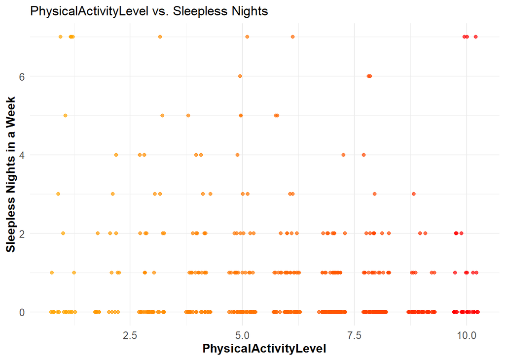

```r
ggplot(df, aes(x = PhysicalActivityLevel, y = SleeplessNightsInAWeek, color = PhysicalActivityLevel)) +
  geom_jitter(width = 0.3, height = 0, alpha = 0.7) +
  scale_color_gradient(low = "orange", high = "red") +
  labs(title = "PhysicalActivityLevel vs. Sleepless Nights",
       x = "PhysicalActivityLevel",
       y = "Sleepless Nights in a Week") +
  theme_minimal() +
  theme(legend.position = "none",
        axis.title = element_text(size = 12, face = "bold"),
        axis.text = element_text(size = 10))
```

**Correlation of Stress Level and Sleepless Nights**

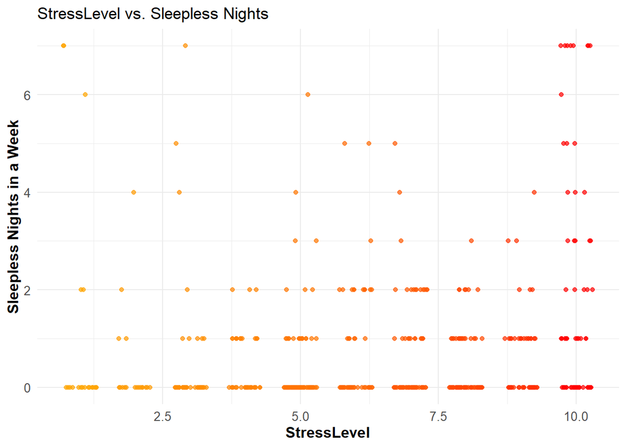

```r
ggplot(df, aes(x = StressLevel, y = SleeplessNightsInAWeek, color = StressLevel)) +
  geom_jitter(width = 0.3, height = 0, alpha = 0.7) +
  scale_color_gradient(low = "orange", high = "red") +
  labs(title = "StressLevel vs. Sleepless Nights",
       x = "StressLevel",
       y = "Sleepless Nights in a Week") +
  theme_minimal() +
  theme(legend.position = "none",
        axis.title = element_text(size = 12, face = "bold"),
        axis.text = element_text(size = 10))
```

**Correlation of Daily Steps vs. Sleepless Nights**

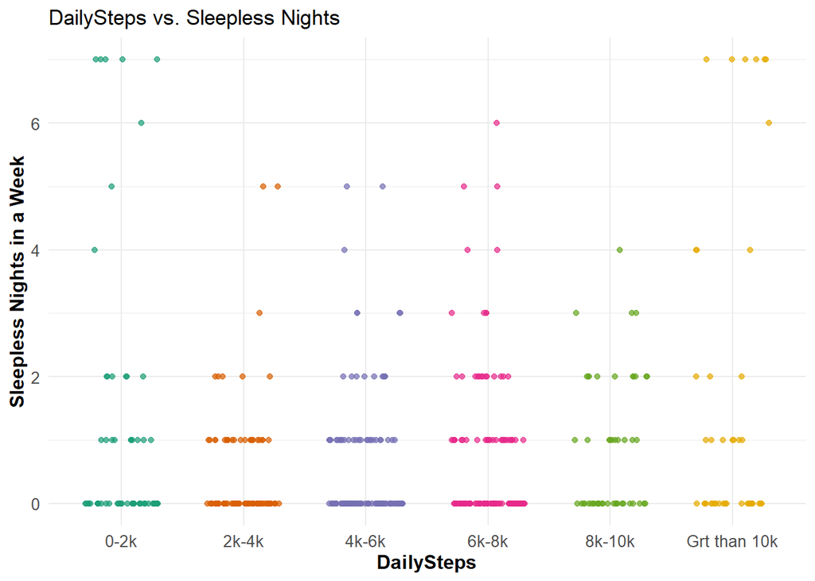

```r
ggplot(df, aes(x = DailySteps, y = SleeplessNightsInAWeek, color = DailySteps)) +
  geom_jitter(width = 0.3, height = 0, alpha = 0.7) +
  scale_color_brewer(palette = "Dark2") +
  labs(title = "DailySteps vs. Sleepless Nights",
       x = "DailySteps",
       y = "Sleepless Nights in a Week") +
  theme_minimal() +
  theme(legend.position = "none",
        axis.title = element_text(size = 12, face = "bold"),
        axis.text = element_text(size = 10))
```

**Correlation of Hours of EC Devices Before Sleep and Sleepless Nights**

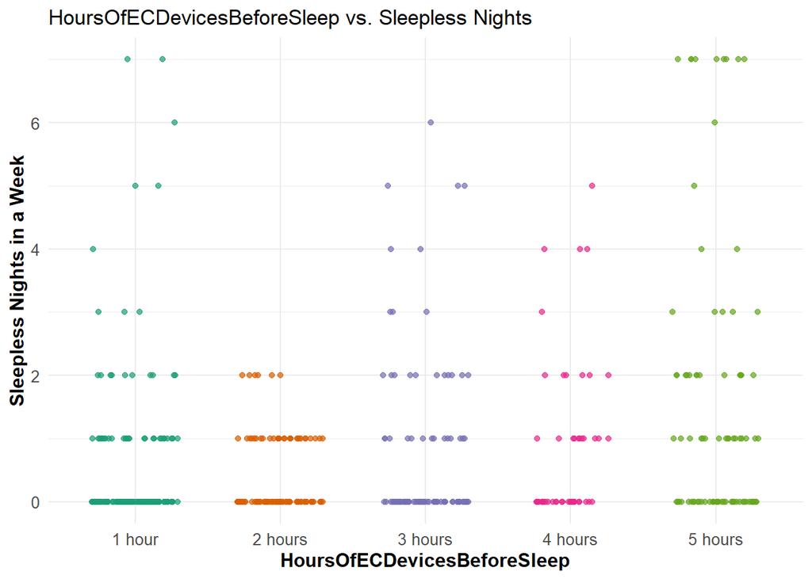

```r
ggplot(df, aes(x = HoursOfECDevicesBeforeSleep, y = SleeplessNightsInAWeek, color = HoursOfECDevicesBeforeSleep)) +
  geom_jitter(width = 0.3, height = 0, alpha = 0.7) +
  scale_color_brewer(palette = "Dark2") +
  labs(title = "HoursOfECDevicesBeforeSleep vs. Sleepless Nights",
       x = "HoursOfECDevicesBeforeSleep",
       y = "Sleepless Nights in a Week") +
  theme_minimal() +
  theme(legend.position = "none",
        axis.title = element_text(size = 12, face = "bold"),
        axis.text = element_text(size = 10))
```

**Correlation of Headache Frequency vs. Sleepless Nights**

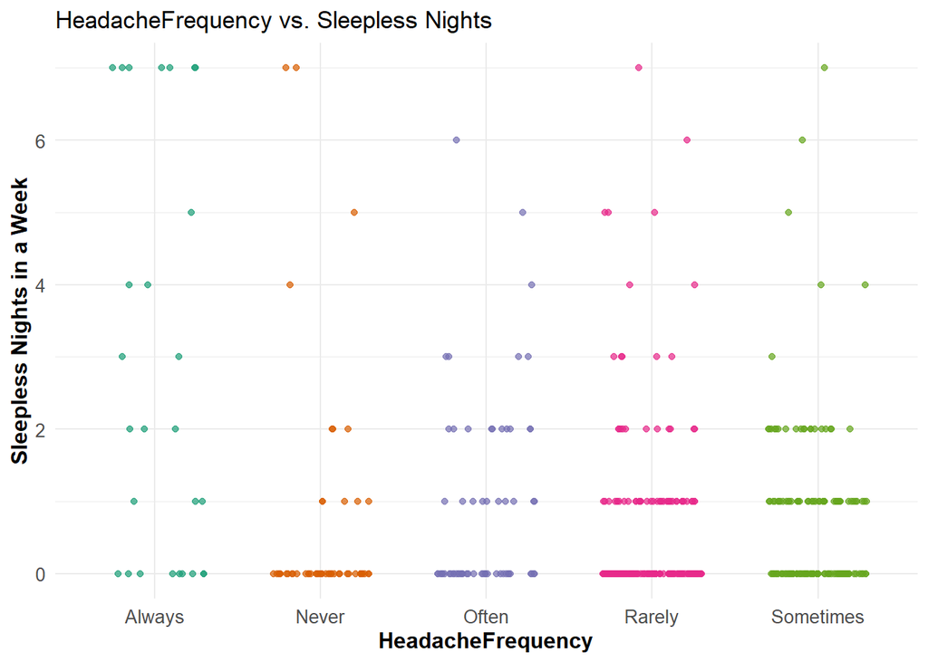

```r
ggplot(df, aes(x = HeadacheFrequency, y = SleeplessNightsInAWeek, color = HeadacheFrequency)) +
  geom_jitter(width = 0.3, height = 0, alpha = 0.7) +
  scale_color_brewer(palette = "Dark2") +
  labs(title = "HeadacheFrequency vs. Sleepless Nights",
       x = "HeadacheFrequency",
       y = "Sleepless Nights in a Week") +
  theme_minimal() +
  theme(legend.position = "none",
        axis.title = element_text(size = 12, face = "bold"),
        axis.text = element_text(size = 10))
```

**Correlation of Breakfast Skip vs. Sleepless Nights**

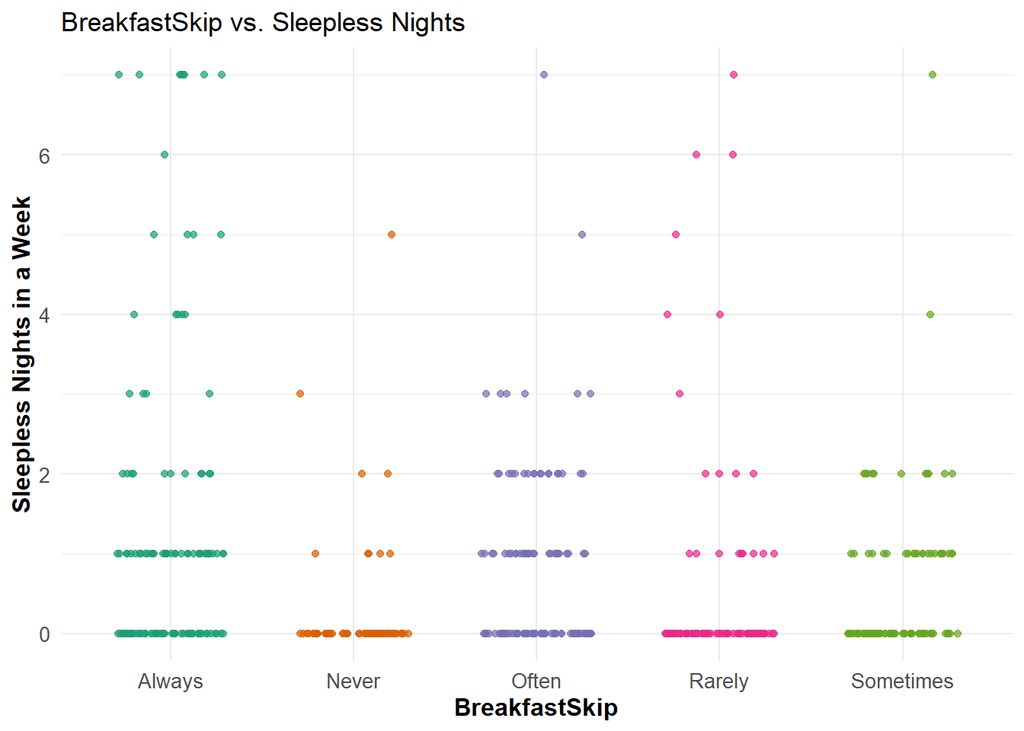

```r
ggplot(df, aes(x = BreakfastSkip, y = SleeplessNightsInAWeek, color = BreakfastSkip)) +
  geom_jitter(width = 0.3, height = 0, alpha = 0.7) +
  scale_color_brewer(palette = "Dark2") +
  labs(title = "BreakfastSkip vs. Sleepless Nights",
       x = "BreakfastSkip",
       y = "Sleepless Nights in a Week") +
  theme_minimal() +
  theme(legend.position = "none",
        axis.title = element_text(size = 12, face = "bold"),
        axis.text = element_text(size = 10))
```

**Correlation of Dinner Time vs. Sleepless Nights**

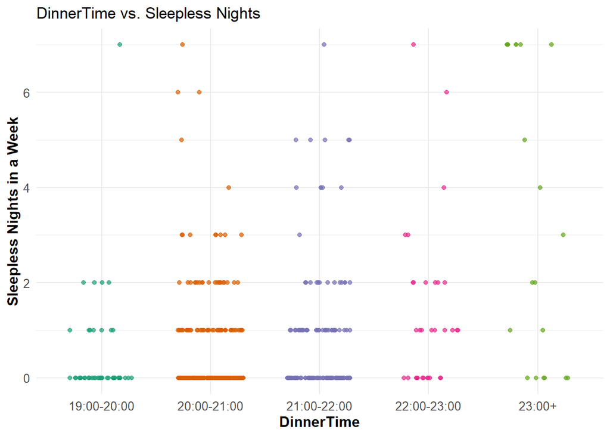

```r
ggplot(df, aes(x = DinnerTime, y = SleeplessNightsInAWeek, color = DinnerTime)) +
  geom_jitter(width = 0.3, height = 0, alpha = 0.7) +
  scale_color_brewer(palette = "Dark2") +
  labs(title = "DinnerTime vs. Sleepless Nights",
       x = "DinnerTime",
       y = "Sleepless Nights in a Week") +
  theme_minimal() +
  theme(legend.position = "none",
        axis.title = element_text(size = 12, face = "bold"),
        axis.text = element_text(size = 10))
```

**Correlation of Gender vs. Quality Of Sleep**

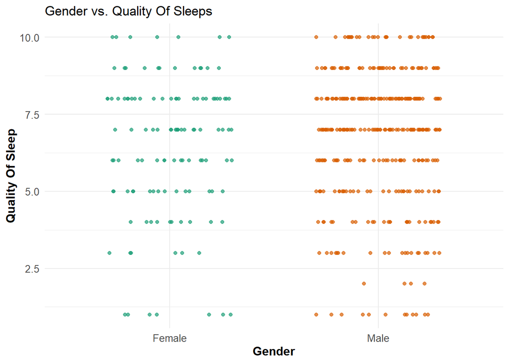

```r
ggplot(df, aes(x = Gender, y = QualityOfSleep, color = Gender)) +
  geom_jitter(width = 0.3, height = 0, alpha = 0.7) +
  scale_color_brewer(palette = "Dark2") +
  labs(title = "Gender vs. Quality Of Sleeps",
       x = "Gender",
       y = "Quality Of Sleep") +
  theme_minimal() +
  theme(legend.position = "none",
        axis.title = element_text(size = 12, face = "bold"),
        axis.text = element_text(size = 10))
```

**Correlation of Age vs. Quality Of Sleep**

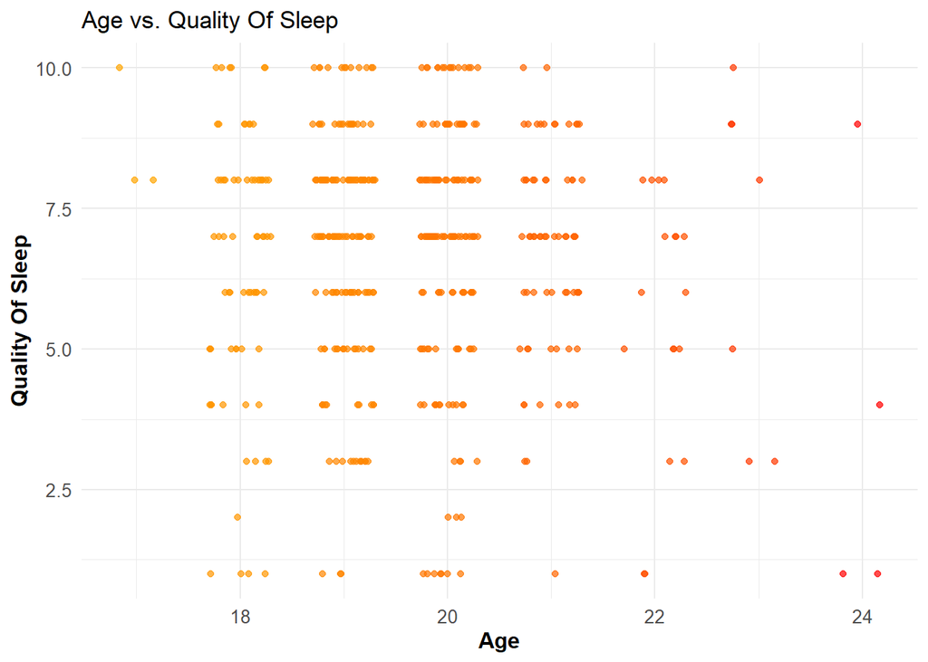

```r
ggplot(df, aes(x = Age, y = QualityOfSleep, color = Age)) +
  geom_jitter(width = 0.3, height = 0, alpha = 0.7) +
  scale_color_gradient(low = "orange", high = "red") +
  labs(title = "Age vs. Quality Of Sleep",
       x = "Age",
       y = "Quality Of Sleep") +
  theme_minimal() +
  theme(legend.position = "none",
        axis.title = element_text(size = 12, face = "bold"),
        axis.text = element_text(size = 10))
```

**Correlation of Year vs. Quality Of Sleep**

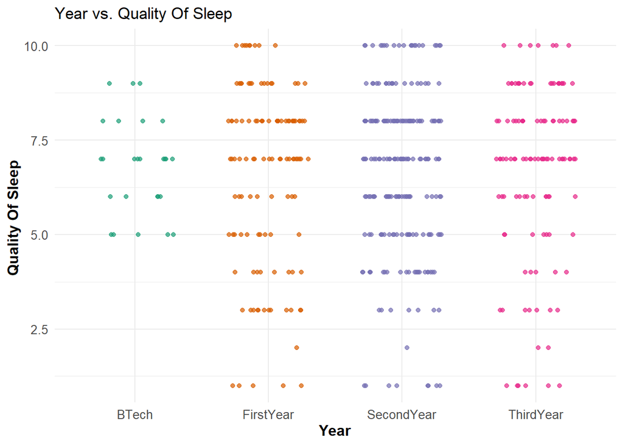

```r
ggplot(df, aes(x = Year, y = QualityOfSleep, color = Year)) +
  geom_jitter(width = 0.3, height = 0, alpha = 0.7) +
  scale_color_brewer(palette = "Dark2") +
  labs(title = "Year vs. Quality Of Sleep",
       x = "Year",
       y = "Quality Of Sleep ") +
  theme_minimal() +
  theme(legend.position = "none",
        axis.title = element_text(size = 12, face = "bold"),
        axis.text = element_text(size = 10))
```

**Correlation of Branch vs. Quality Of Sleep**

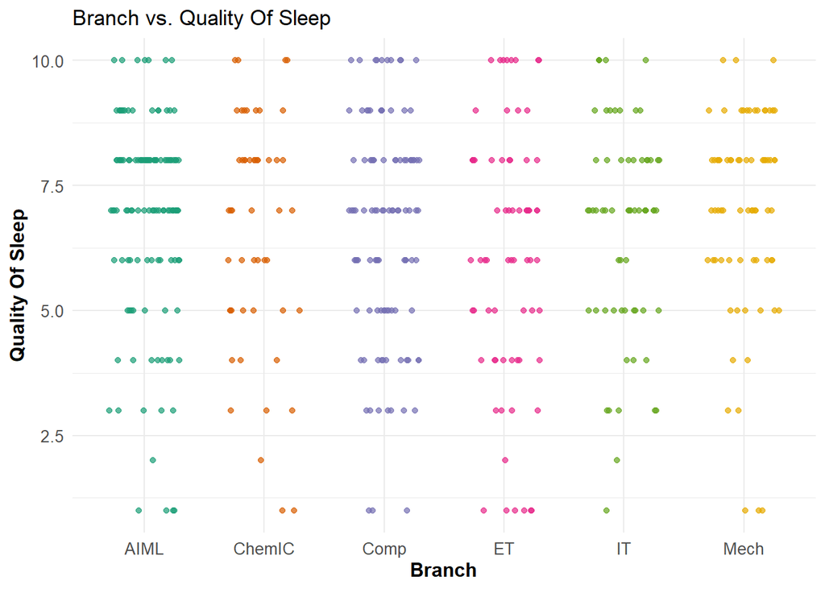

```r
ggplot(df, aes(x = Branch, y = QualityOfSleep, color = Branch)) +
  geom_jitter(width = 0.3, height = 0, alpha = 0.7) +
  scale_color_brewer(palette = "Dark2") +
  labs(title = "Branch vs. Quality Of Sleep",
       x = "Branch",
       y = "Quality Of Sleep") +
  theme_minimal() +
  theme(legend.position = "none",
        axis.title = element_text(size = 12, face = "bold"),
        axis.text = element_text(size = 10))
```

**Correlation of Hours of Sleep vs. Quality of Sleep**

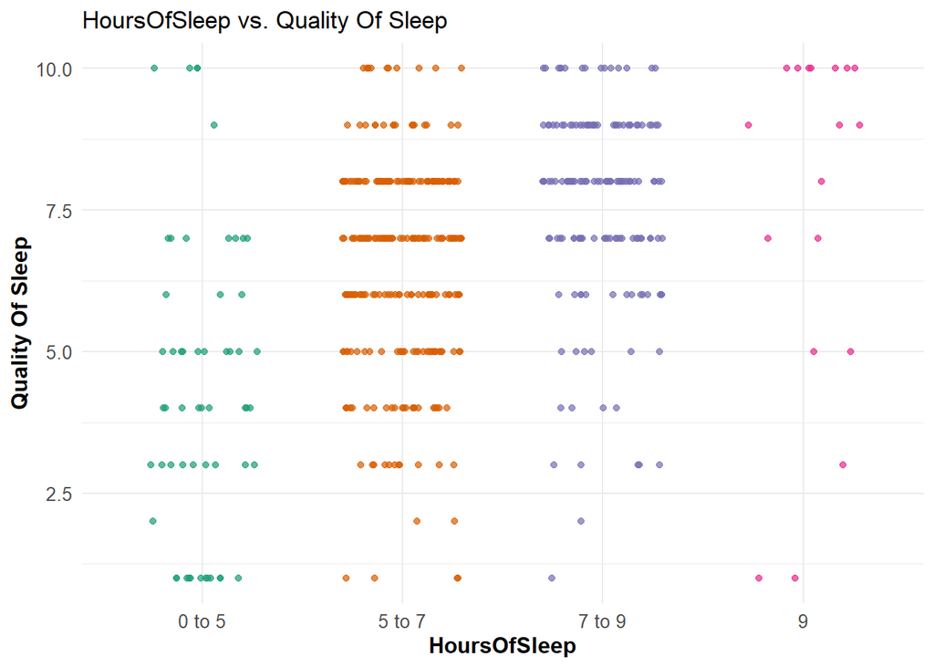

```r
ggplot(df, aes(x = HoursOfSleep, y = QualityOfSleep, color = HoursOfSleep)) +
  geom_jitter(width = 0.3, height = 0, alpha = 0.7) +
  scale_color_brewer(palette = "Dark2") +
  labs(title = "HoursOfSleep vs. Quality Of Sleep",
       x = "HoursOfSleep",
       y = "Quality Of Sleep") +
  theme_minimal() +
  theme(legend.position = "none",
        axis.title = element_text(size = 12, face = "bold"),
        axis.text = element_text(size = 10))
```

**Correlation of Naps In A Week vs. Quality Of Sleep**

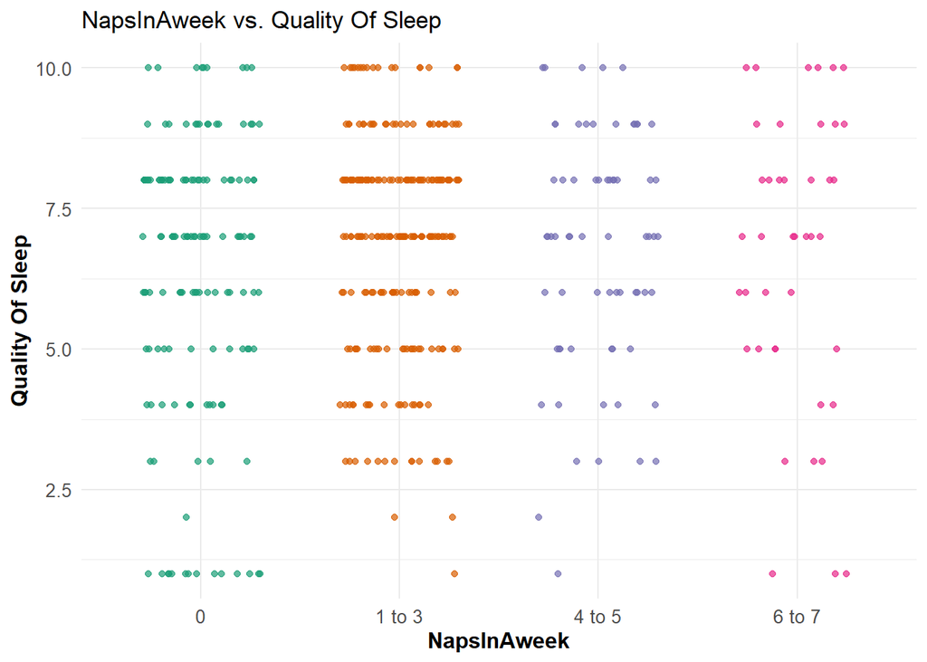

```r
ggplot(df, aes(x = NapsInAweek, y = QualityOfSleep, color = NapsInAweek)) +
  geom_jitter(width = 0.3, height = 0, alpha = 0.7) +
  scale_color_brewer(palette = "Dark2") +
  labs(title = "NapsInAweek vs. Quality Of Sleep",
       x = "NapsInAweek",
       y = "Quality Of Sleep") +
  theme_minimal() +
  theme(legend.position = "none",
        axis.title = element_text(size = 12, face = "bold"),
        axis.text = element_text(size = 10))
```

**Correlation of Physical Activity Level vs. Quality Of Sleep**

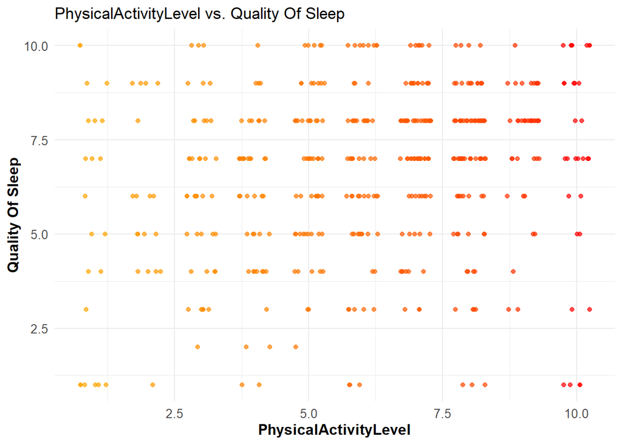

```r
ggplot(df, aes(x = PhysicalActivityLevel, y = QualityOfSleep, color = PhysicalActivityLevel)) +
  geom_jitter(width = 0.3, height = 0, alpha = 0.7) +
  scale_color_gradient(low = "orange", high = "red") +
  labs(title = "PhysicalActivityLevel vs. Quality Of Sleep",
       x = "PhysicalActivityLevel",
       y = "Quality Of Sleep") +
  theme_minimal() +
  theme(legend.position = "none",
        axis.title = element_text(size = 12, face = "bold"),
        axis.text = element_text(size = 10))
```

**Correlation of Stress Level vs. Quality Of Sleep**

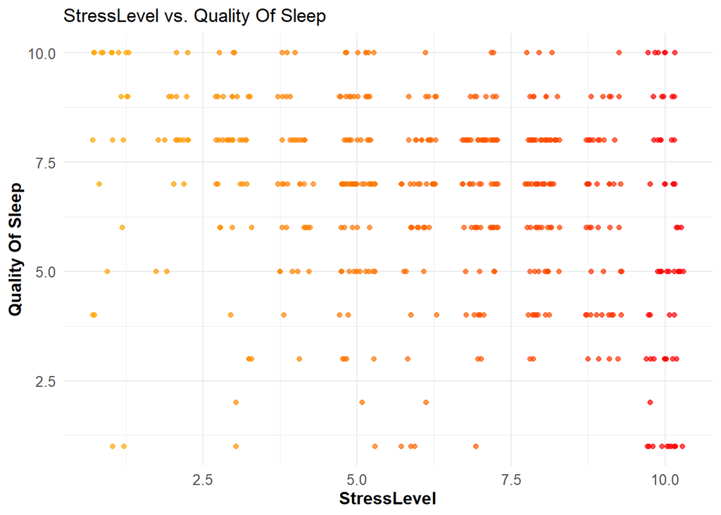

```r
ggplot(df, aes(x = StressLevel, y = QualityOfSleep, color = StressLevel)) +
  geom_jitter(width = 0.3, height = 0, alpha = 0.7) +
  scale_color_gradient(low = "orange", high = "red") +
  labs(title = "StressLevel vs. Quality Of Sleep",
       x = "StressLevel",
       y = "Quality Of Sleep") +
  theme_minimal() +
  theme(legend.position = "none",
        axis.title = element_text(size = 12, face = "bold"),
        axis.text = element_text(size = 10))
```

**Correlation of Daily Steps vs. Quality Of Sleep**

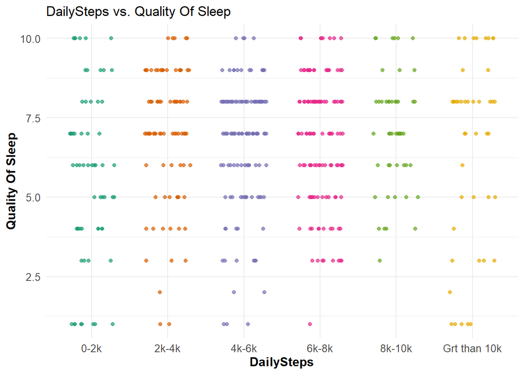

```r
ggplot(df, aes(x = DailySteps, y = QualityOfSleep, color = DailySteps)) +
  geom_jitter(width = 0.3, height = 0, alpha = 0.7) +
  scale_color_brewer(palette = "Dark2") +
  labs(title = "DailySteps vs. Quality Of Sleep",
       x = "DailySteps",
       y = "Quality Of Sleep") +
  theme_minimal() +
  theme(legend.position = "none",
        axis.title = element_text(size = 12, face = "bold"),
        axis.text = element_text(size = 10))
```

**Correlation of Hours of EC Devices Before Sleep vs. Quality Of Sleep**

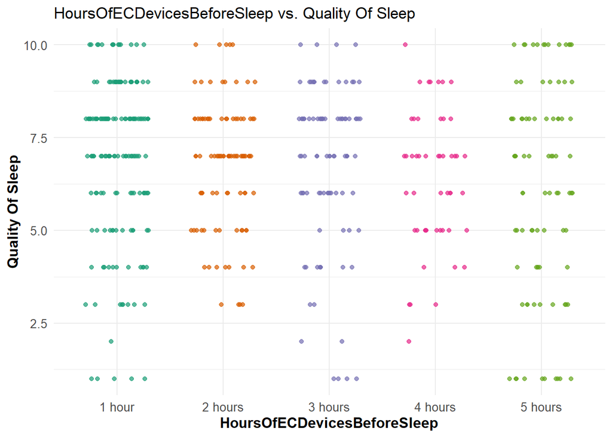

```r
ggplot(df, aes(x = HoursOfECDevicesBeforeSleep, y = QualityOfSleep, color = HoursOfECDevicesBeforeSleep)) +
  geom_jitter(width = 0.3, height = 0, alpha = 0.7) +
  scale_color_brewer(palette = "Dark2") +
  labs(title = "HoursOfECDevicesBeforeSleep vs. Quality Of Sleep",
       x = "HoursOfECDevicesBeforeSleep",
       y = "Quality Of Sleep") +
  theme_minimal() +
  theme(legend.position = "none",
        axis.title = element_text(size = 12, face = "bold"),
        axis.text = element_text(size = 10))
```

**Correlation of Headache Frequency vs. Quality Of Sleep**

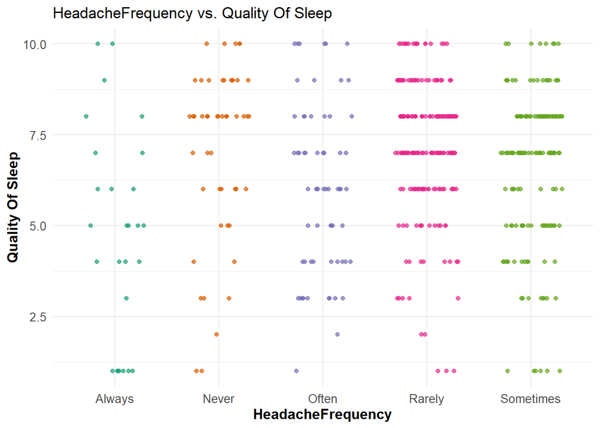

```r
ggplot(df, aes(x = HeadacheFrequency, y = QualityOfSleep, color = HeadacheFrequency)) +
  geom_jitter(width = 0.3, height = 0, alpha = 0.7) +
  scale_color_brewer(palette = "Dark2") +
  labs(title = "HeadacheFrequency vs. Quality Of Sleep",
       x = "HeadacheFrequency",
       y = "Quality Of Sleep") +
  theme_minimal() +
  theme(legend.position = "none",
        axis.title = element_text(size = 12, face = "bold"),
        axis.text = element_text(size = 10))
```

**Correlation of Breakfast Skip vs. Quality Of Sleep**

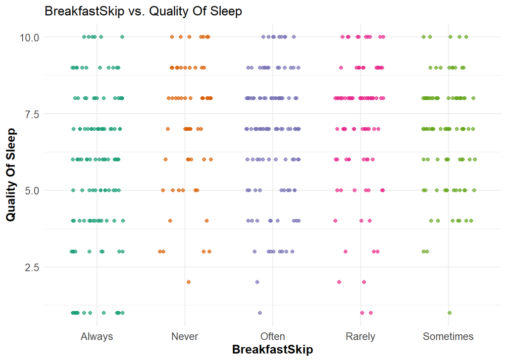

```r
ggplot(df, aes(x = BreakfastSkip, y = QualityOfSleep, color = BreakfastSkip)) +
  geom_jitter(width = 0.3, height = 0, alpha = 0.7) +
  scale_color_brewer(palette = "Dark2") +
  labs(title = "BreakfastSkip vs. Quality Of Sleep",
       x = "BreakfastSkip",
       y = "Quality Of Sleep") +
  theme_minimal() +
  theme(legend.position = "none",
        axis.title = element_text(size = 12, face = "bold"),
        axis.text = element_text(size = 10))
```

**Correlation of Dinner Time vs. Quality Of Sleep**

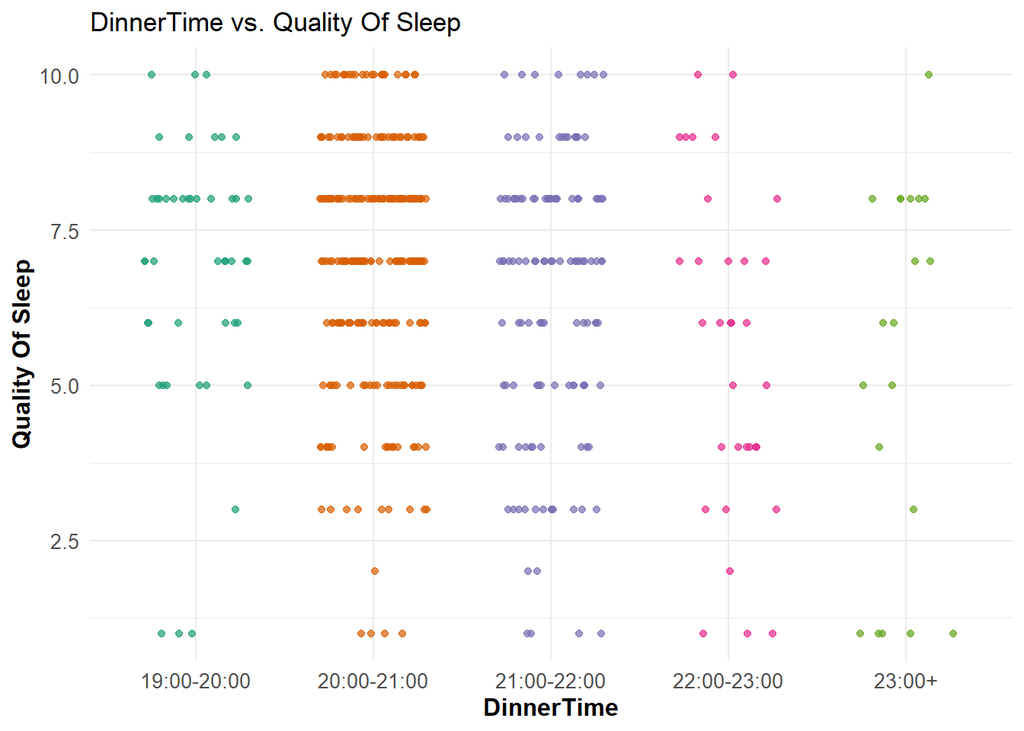

```r
ggplot(df, aes(x = DinnerTime, y = QualityOfSleep, color = DinnerTime)) +
  geom_jitter(width = 0.3, height = 0, alpha = 0.7) +
  scale_color_brewer(palette = "Dark2") +
  labs(title = "DinnerTime vs. Quality Of Sleep",
       x = "DinnerTime",
       y = "Quality Of Sleep") +
  theme_minimal() +
  theme(legend.position = "none",
        axis.title = element_text(size = 12, face = "bold"),
        axis.text = element_text(size = 10))
```

**One Hot Encoding on columns such as Gender, Branch and Year**

```r
categorical_cols1 <- c("Gender", "Branch", "Year")

encoded_data1 <- cbind(df[, !names(df) %in% categorical_cols1],
                      model.matrix(~ . - 1, data = df[categorical_cols1]))

head(encoded_data1)
```

|  | Age | HoursOfSleep | QualityOfSleep | NapsInAweek | PhysicalActivityLevel | StressLevel | DailySteps | HoursOfECDevicesBeforeSleep | HeadacheFrequency | BreakfastSkip | DinnerTime | SleeplessNightsInAWeek | GenderFemale | GenderMale | BranchChemIC | BranchComp | BranchET | BranchIT | BranchMech | YearFirstYear | YearSecondYear | YearThirdYear |
| --- | --- | --- | --- | --- | --- | --- | --- | --- | --- | --- | --- | --- | --- | --- | --- | --- | --- | --- | --- | --- | --- | --- |
| 1 | 18 | 0 to 5 | 4 | 0 | 9 | 10 | 6k-8k | 1 hour | Rarely | Always | 20:00-21:00 | 3 | 0 | 1 | 0 | 1 | 0 | 0 | 0 | 0 | 1 | 0 |
| 2 | 19 | 7 to 9 | 8 | 0 | 5 | 10 | 6k-8k | 2 hours | Rarely | Never | 21:00-22:00 | 1 | 0 | 1 | 0 | 1 | 0 | 0 | 0 | 0 | 1 | 0 |
| 3 | 19 | 7 to 9 | 6 | 1 to 3 | 5 | 7 | 6k-8k | 2 hours | Never | Always | 19:00-20:00 | 1 | 1 | 0 | 0 | 1 | 0 | 0 | 0 | 0 | 1 | 0 |
| 4 | 19 | 7 to 9 | 7 | 1 to 3 | 5 | 10 | 4k-6k | 5 hours | Rarely | Never | 21:00-22:00 | 0 | 1 | 0 | 0 | 1 | 0 | 0 | 0 | 0 | 1 | 0 |
| 5 | 20 | 5 to 7 | 10 | 0 | 10 | 1 | 0-2k | 1 hour | Never | Rarely | 19:00-20:00 | 0 | 0 | 1 | 0 | 1 | 0 | 0 | 0 | 0 | 1 | 0 |
| 6 | 20 | 7 to 9 | 8 | 6 to 7 | 7 | 10 | 4k-6k | 3 hours | Sometimes | Never | 20:00-21:00 | 0 | 1 | 0 | 0 | 0 | 0 | 1 | 0 | 0 | 1 | 0 |

**Label Encoding on columns Hours Of Sleep, Naps In A week, Daily Steps, Hours Of EC Devices Before Sleep, Headache Frequency, Breakfast Skip, Dinner Time**

```r
categorical_cols2 <- c("HoursOfSleep", "NapsInAweek", "DailySteps", "HoursOfECDevicesBeforeSleep", "HeadacheFrequency","BreakfastSkip","DinnerTime")

label_encode <- function(x) {
  levels <- unique(x)
  as.integer(factor(x, levels = levels))
}

for (col in categorical_cols2) {
  encoded_data1[[col]] <- label_encode(encoded_data1[[col]])
}

head(encoded_data1)
```

|  | Age | HoursOfSleep | QualityOfSleep | NapsInAweek | PhysicalActivityLevel | StressLevel | DailySteps | HoursOfECDevicesBeforeSleep | HeadacheFrequency | BreakfastSkip | DinnerTime | SleeplessNightsInAWeek | GenderFemale | GenderMale | BranchChemIC | BranchComp | BranchET | BranchIT | BranchMech | YearFirstYear | YearSecondYear | YearThirdYear |
| --- | --- | --- | --- | --- | --- | --- | --- | --- | --- | --- | --- | --- | --- | --- | --- | --- | --- | --- | --- | --- | --- | --- |
| 1 | 18 | 1 | 4 | 1 | 9 | 10 | 1 | 1 | 1 | 1 | 1 | 3 | 0 | 1 | 0 | 1 | 0 | 0 | 0 | 0 | 1 | 0 |
| 2 | 19 | 2 | 8 | 1 | 5 | 10 | 1 | 2 | 1 | 2 | 2 | 1 | 0 | 1 | 0 | 1 | 0 | 0 | 0 | 0 | 1 | 0 |
| 3 | 19 | 2 | 6 | 2 | 5 | 7 | 1 | 2 | 2 | 1 | 3 | 1 | 1 | 0 | 0 | 1 | 0 | 0 | 0 | 0 | 1 | 0 |
| 4 | 19 | 2 | 7 | 2 | 5 | 10 | 2 | 3 | 1 | 2 | 2 | 0 | 1 | 0 | 0 | 1 | 0 | 0 | 0 | 0 | 1 | 0 |
| 5 | 20 | 3 | 10 | 1 | 10 | 1 | 3 | 1 | 2 | 3 | 3 | 0 | 0 | 1 | 0 | 1 | 0 | 0 | 0 | 0 | 1 | 0 |
| 6 | 20 | 2 | 8 | 3 | 7 | 10 | 2 | 4 | 3 | 2 | 1 | 0 | 1 | 0 | 0 | 0 | 0 | 1 | 0 | 0 | 1 | 0 |

**Summary of values in the encoded data**

```r
summary(encoded_data1)
```

```
##       Age         HoursOfSleep   QualityOfSleep   NapsInAweek
##  Min.   :17.00   Min.   :1.000   Min.   : 1.00   Min.   :1.00
##  1st Qu.:19.00   1st Qu.:2.000   1st Qu.: 5.00   1st Qu.:1.00
##  Median :20.00   Median :3.000   Median : 7.00   Median :2.00
##  Mean   :19.64   Mean   :2.491   Mean   : 6.66   Mean   :2.07
##  3rd Qu.:20.00   3rd Qu.:3.000   3rd Qu.: 8.00   3rd Qu.:2.00
##  Max.   :24.00   Max.   :4.000   Max.   :10.00   Max.   :4.00
##  PhysicalActivityLevel  StressLevel       DailySteps
##  Min.   : 1.000        Min.   : 1.000   Min.   :1.000
##  1st Qu.: 4.000        1st Qu.: 5.000   1st Qu.:1.000
##  Median : 6.000        Median : 7.000   Median :2.000
##  Mean   : 6.083        Mean   : 6.325   Mean   :3.048
##  3rd Qu.: 8.000        3rd Qu.: 8.000   3rd Qu.:5.000
##  Max.   :10.000        Max.   :10.000   Max.   :6.000
##  HoursOfECDevicesBeforeSleep HeadacheFrequency BreakfastSkip     DinnerTime
##  Min.   :1.000               Min.   :1.000     Min.   :1.000   Min.   :1.000
##  1st Qu.:1.000               1st Qu.:1.000     1st Qu.:1.500   1st Qu.:1.000
##  Median :2.000               Median :3.000     Median :3.000   Median :1.000
##  Mean   :2.542               Mean   :2.427     Mean   :3.046   Mean   :1.824
##  3rd Qu.:4.000               3rd Qu.:3.000     3rd Qu.:4.000   3rd Qu.:2.000
##  Max.   :5.000               Max.   :5.000     Max.   :5.000   Max.   :5.000
##  SleeplessNightsInAWeek  GenderFemale      GenderMale      BranchChemIC
##  Min.   :0.0000         Min.   :0.0000   Min.   :0.0000   Min.   :0.0000
##  1st Qu.:0.0000         1st Qu.:0.0000   1st Qu.:0.5000   1st Qu.:0.0000
##  Median :0.0000         Median :0.0000   Median :1.0000   Median :0.0000
##  Mean   :0.8054         Mean   :0.2505   Mean   :0.7495   Mean   :0.1056
##  3rd Qu.:1.0000         3rd Qu.:0.5000   3rd Qu.:1.0000   3rd Qu.:0.0000
##  Max.   :7.0000         Max.   :1.0000   Max.   :1.0000   Max.   :1.0000
##    BranchComp        BranchET         BranchIT        BranchMech
##  Min.   :0.0000   Min.   :0.0000   Min.   :0.0000   Min.   :0.0000
##  1st Qu.:0.0000   1st Qu.:0.0000   1st Qu.:0.0000   1st Qu.:0.0000
##  Median :0.0000   Median :0.0000   Median :0.0000   Median :0.0000
##  Mean   :0.2174   Mean   :0.1429   Mean   :0.1325   Mean   :0.1491
##  3rd Qu.:0.0000   3rd Qu.:0.0000   3rd Qu.:0.0000   3rd Qu.:0.0000
##  Max.   :1.0000   Max.   :1.0000   Max.   :1.0000   Max.   :1.0000
##  YearFirstYear    YearSecondYear   YearThirdYear
##  Min.   :0.0000   Min.   :0.0000   Min.   :0.0000
##  1st Qu.:0.0000   1st Qu.:0.0000   1st Qu.:0.0000
##  Median :0.0000   Median :0.0000   Median :0.0000
##  Mean   :0.2505   Mean   :0.4534   Mean   :0.2422
##  3rd Qu.:0.5000   3rd Qu.:1.0000   3rd Qu.:0.0000
##  Max.   :1.0000   Max.   :1.0000   Max.   :1.0000
```

**Correlation Data**

```r
cor_data = cor(encoded_data1)

print("Correlation matrix")
```

```
## [1] "Correlation matrix"
```

```r
print(cor_data)
```

```
##                                       Age HoursOfSleep QualityOfSleep
## Age                          1.0000000000  0.033762394   -0.064978547
## HoursOfSleep                 0.0337623938  1.000000000    0.165779918
## QualityOfSleep              -0.0649785473  0.165779918    1.000000000
## NapsInAweek                  0.0740310278  0.058065650    0.055304049
## PhysicalActivityLevel       -0.0660982105  0.028484226    0.214412224
## StressLevel                  0.0254004948  0.011973014   -0.261375464
## DailySteps                   0.1602162679  0.001092813    0.030770377
## HoursOfECDevicesBeforeSleep  0.1145728842  0.043172939   -0.079924854
## HeadacheFrequency            0.0180198578 -0.047961809   -0.223733218
## BreakfastSkip               -0.0001922321  0.022479850    0.159467328
## DinnerTime                   0.1706271755 -0.045554203   -0.194171573
## SleeplessNightsInAWeek       0.0821686606 -0.113940036   -0.454917441
## GenderFemale                -0.1247743470  0.048860592   -0.064441446
## GenderMale                   0.1247743470 -0.048860592    0.064441446
## BranchChemIC                 0.1659748781 -0.009256873   -0.008149904
## BranchComp                  -0.0789105341 -0.097726262   -0.018890978
## BranchET                     0.0778329231  0.064592978   -0.105554949
## BranchIT                    -0.1661656772 -0.027867043   -0.003494121
## BranchMech                   0.2143160565 -0.057121839    0.061450512
## YearFirstYear               -0.4477000516 -0.015199305   -0.014896147
## YearSecondYear              -0.1511226220  0.025316326   -0.006824476
## YearThirdYear                0.4068806508 -0.002655937    0.014655164
##                              NapsInAweek PhysicalActivityLevel  StressLevel
## Age                          0.074031028          -0.066098210  0.025400495
## HoursOfSleep                 0.058065650           0.028484226  0.011973014
## QualityOfSleep               0.055304049           0.214412224 -0.261375464
## NapsInAweek                  1.000000000          -0.050993553 -0.006753374
## PhysicalActivityLevel       -0.050993553           1.000000000 -0.108038881
## StressLevel                 -0.006753374          -0.108038881  1.000000000
## DailySteps                  -0.030101103          -0.004278371  0.003827130
## HoursOfECDevicesBeforeSleep  0.044159450          -0.046601811  0.066086904
## HeadacheFrequency            0.075712414          -0.243971510  0.330270424
## BreakfastSkip                0.043073342           0.027288444 -0.005487024
## DinnerTime                  -0.063146057          -0.093036727  0.082316362
## SleeplessNightsInAWeek       0.028668345          -0.175821709  0.165613454
## GenderFemale                -0.007466008          -0.126780221  0.146015126
## GenderMale                   0.007466008           0.126780221 -0.146015126
## BranchChemIC                 0.023653644          -0.048855365 -0.001531189
## BranchComp                  -0.136395127          -0.045850849 -0.002232562
```

[output cut: 129 more lines]

```
## HoursOfECDevicesBeforeSleep   0.057960128
## HeadacheFrequency             0.041953593
## BreakfastSkip                 0.037422956
## DinnerTime                    0.050249905
## SleeplessNightsInAWeek        0.025741691
## GenderFemale                 -0.092682326
## GenderMale                    0.092682326
## BranchChemIC                  0.120231668
## BranchComp                   -0.075388827
## BranchET                      0.128234315
## BranchIT                     -0.121197659
## BranchMech                    0.143268114
## YearFirstYear                -0.326881836
## YearSecondYear               -0.514958798
## YearThirdYear                 1.000000000
```

The correlation matrix shows the pairwise correlations between different variables in our dataset. When the value is close to 1 or -1, it will show a strong positive or negative correlation respectively.

For example, the relationship b/w ‘QualityOfSleep’ and ‘PhysicalActivity’ is 0.214 which indicates a moderate positive correlation. When one will increase the other will also increase. Similarly, the relationship b/w ‘QualityOfSleep’ and ‘StressLevel’ is -0.261 which indicates a moderate negative correlation. When one will increase the other will decrease.

**Heatmap of the Correlation Matrix**

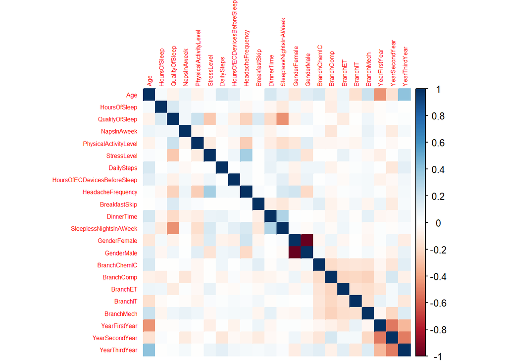

```r
library(corrplot)
correlation_matrix <- cor(encoded_data1)

corrplot::corrplot(correlation_matrix, method = "color", tl.cex = 0.5)
```

**Pair plot of Quality Of Sleep, Sleepless Nights In A Week, Naps In A Week, and Hours Of Sleep**

```r
library(GGally)
```

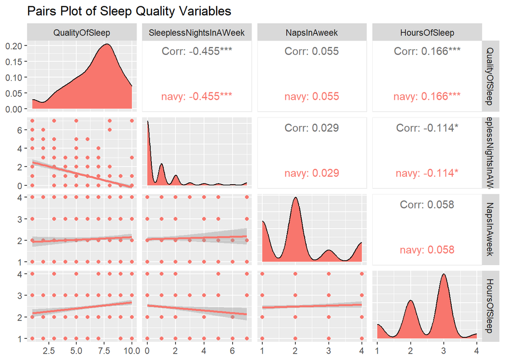

```r
pairs_plot <- ggpairs(encoded_data1[, c("QualityOfSleep", "SleeplessNightsInAWeek", "NapsInAweek", "HoursOfSleep")],
                    lower = list(continuous = "smooth"),
                    diag = list(continuous = "density"),
                    upper = list(continuous = "cor"),
                    title = "Pairs Plot of Sleep Quality Variables",
                    mapping = aes(color = "navy"),
                    labels = c("Quality of Sleep", "Sleepless Nights In A Week", "Naps In A week", "Hours of Sleep"))
print(pairs_plot)
```

1. “QualityOfSleep” and “SleeplessNightsInAWeek”: Correlation value: -0.455 Interpretation: This indicates a relatively strong negative correlation between the quality of sleep and the number of sleepless nights in a week.
2. “QualityOfSleep” and “NapsInAweek”: Correlation value: 0.055 Interpretation: This indicates a very weak positive correlation between the quality of sleep and the number of naps taken in a week.
3. “QualityOfSleep” and “HoursOfSleep”: Correlation value: 0.166 Interpretation: This indicates a relatively weak positive correlation between the quality of sleep and the number of hours slept per night.
4. “SleeplessNightsInAWeek” and “HoursOfSleep”: Correlation value: -0.114 Interpretation: This indicates a weak negative correlation between the number of sleepless nights in a week and the number of hours slept per night.

**Pair plot of Quality Of Sleep, Sleepless Nights In A Week, Daily Steps , and Physical Activity Level**

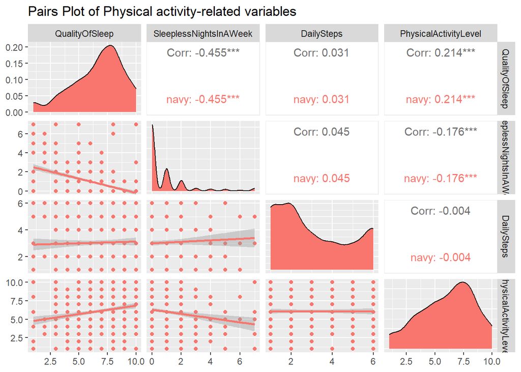

```r
pairs_plot <- ggpairs(encoded_data1[, c("QualityOfSleep", "SleeplessNightsInAWeek", "DailySteps", "PhysicalActivityLevel")],
                    lower = list(continuous = "smooth"),
                    diag = list(continuous = "density"),
                    upper = list(continuous = "cor"),
                    title = "Pairs Plot of Physical activity-related variables",
                    mapping = aes(color = "navy"),
                    labels = c("Quality of Sleep", "Sleepless Nights In A Week", "Daily Steps", "Physical Activity Level"))
print(pairs_plot)
```

1. “QualityOfSleep” and “SleeplessNightsInAWeek”: Correlation value: -0.455 Interpretation: This indicates a relatively strong negative correlation between the quality of sleep and the number of sleepless nights in a week.
2. “QualityOfSleep” and “DailySteps”: Correlation value: 0.031 Interpretation: This indicates a very weak positive correlation between the quality of sleep and the number of daily steps taken.
3. “QualityOfSleep” and “PhysicalActivityLevel”: Correlation value: 0.214 Interpretation: This indicates a positive correlation between the quality of sleep and the level of physical activity.
4. “SleeplessNightsInAWeek” and “DailySteps”: Correlation value: 0.045 Interpretation: This indicates a very weak positive correlation between the number of sleepless nights in a week and the number of daily steps taken.

**Pair plot of Quality Of Sleep, Sleepless Nights In A Week, Stress Level , Headache Frequency and Hours Of EC Devices Before Sleep**

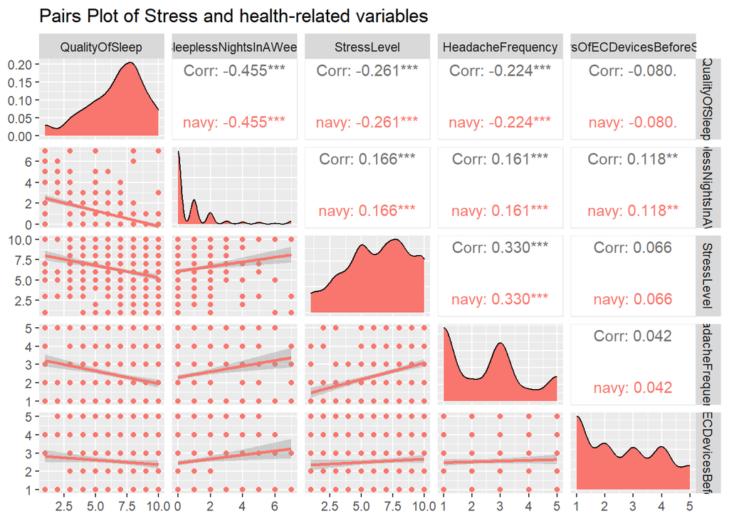

```r
pairs_plot <- ggpairs(encoded_data1[, c("QualityOfSleep", "SleeplessNightsInAWeek", "StressLevel", "HeadacheFrequency",
                                        "HoursOfECDevicesBeforeSleep")],
                    lower = list(continuous = "smooth"),
                    diag = list(continuous = "density"),
                    upper = list(continuous = "cor"),
                    title = "Pairs Plot of Stress and health-related variables",
                    mapping = aes(color = "navy"),
                    labels = c("Quality of Sleep", "Sleepless Nights In A Week", "Stress Level", "Headache Frequency",
                               "HoursOfECDevicesBeforeSleep"))
print(pairs_plot)
```

1. “QualityOfSleep” and “SleeplessNightsInAWeek”: Correlation value: -0.455 Interpretation: This indicates a relatively strong negative correlation between the quality of sleep and the number of sleepless nights in a week.
2. “QualityOfSleep” and “StressLevel”: Correlation value: -0.261 Interpretation: This indicates a moderate negative correlation between the quality of sleep and the level of stress.
3. “QualityOfSleep” and “HeadacheFrequency”: Correlation value: -0.224 Interpretation: This indicates a moderate negative correlation between the quality of sleep and the frequency of headaches.
4. “SleeplessNightsInAWeek” and “StressLevel”: Correlation value: 0.166 Interpretation: This indicates a weak positive correlation between the number of sleepless nights in a week and the level of stress.

**Correlation Matrix between Quality Of Sleep, Sleepless Nights In A Week, Gender and Age**

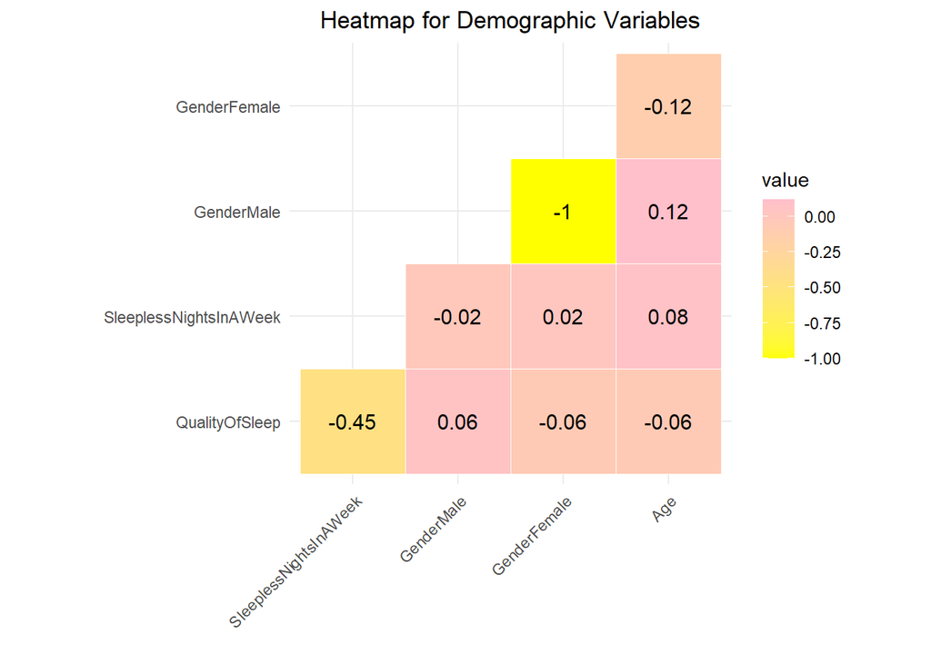

```r
library(ggplot2)
library(GGally)
library(ggcorrplot)

cor_matrix <- cor(encoded_data1[, c("QualityOfSleep", "SleeplessNightsInAWeek", "GenderMale","GenderFemale" , "Age")])

heatmap_plot <- ggcorrplot(cor_matrix, type = "lower", outline.color = "white", lab = TRUE)

heatmap_plot +
  labs(title = "Heatmap for Demographic Variables",
       x = "", y = "") +
  theme_minimal() +  # Apply a minimal theme
  theme(
    axis.text.x = element_text(angle = 45, hjust = 1),
    axis.text.y = element_text(angle = 0, hjust = 1),
    legend.position = "right",
    plot.title = element_text(hjust = 0.5)
  ) +
  scale_fill_gradient(low = "yellow", high = "pink")
```

**Correlation Matrix between Quality Of Sleep, Sleepless Nights In A Week, Year and Branch**

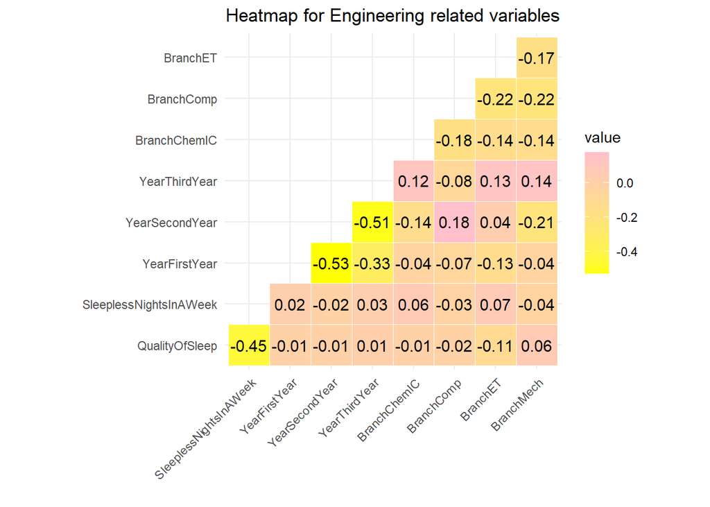

```r
cor_matrix <- cor(encoded_data1[, c("QualityOfSleep", "SleeplessNightsInAWeek", "YearFirstYear","YearSecondYear"
                                    , "YearThirdYear", "BranchChemIC", "BranchComp", "BranchET","BranchMech")])

heatmap_plot <- ggcorrplot(cor_matrix, type = "lower", outline.color = "white", lab = TRUE)

heatmap_plot +
  labs(title = "Heatmap for Engineering related variables",
       x = "", y = "") +
  theme_minimal() +  # Apply a minimal theme
  theme(
    axis.text.x = element_text(angle = 45, hjust = 1),
    axis.text.y = element_text(angle = 0, hjust = 1),
    legend.position = "right",
    plot.title = element_text(hjust = 0.5)
  ) +
  scale_fill_gradient(low = "yellow", high = "pink")
```

1. “QualityOfSleep” and “SleeplessNightsInAWeek”: Correlation value: -0.455 Interpretation: This indicates a relatively strong negative correlation between the quality of sleep and the number of sleepless nights in a week.
2. “QualityOfSleep” and “YearFirstYear”, “YearSecondYear”, “YearThirdYear”: Correlation values: -0.015, -0.007, 0.015, respectively Interpretation: These correlation values indicate very weak correlations between the quality of sleep and the academic year.
3. “QualityOfSleep” and “BranchChemIC”, “BranchComp”, “BranchET”, “BranchMech”: Correlation values: -0.008, -0.019, -0.106, 0.061, respectively Interpretation: These correlation values indicate very weak correlations between the quality of sleep and the branches of study.

**Performing Principal Component Analysis(PCA) on the encoded data**

```r
pca_result <- prcomp(encoded_data1, scale. = TRUE)

summary(pca_result)
```

```
## Importance of components:
##                           PC1    PC2     PC3     PC4     PC5     PC6     PC7
## Standard deviation     1.5643 1.5219 1.33168 1.29883 1.15485 1.11579 1.07996
## Proportion of Variance 0.1112 0.1053 0.08061 0.07668 0.06062 0.05659 0.05301
## Cumulative Proportion  0.1112 0.2165 0.29711 0.37379 0.43441 0.49100 0.54401
##                            PC8     PC9    PC10    PC11    PC12    PC13    PC14
## Standard deviation     1.05844 1.01993 1.00797 0.96604 0.95422 0.93312 0.90679
## Proportion of Variance 0.05092 0.04728 0.04618 0.04242 0.04139 0.03958 0.03738
## Cumulative Proportion  0.59494 0.64222 0.68840 0.73082 0.77221 0.81179 0.84916
##                           PC15    PC16    PC17    PC18    PC19    PC20    PC21
## Standard deviation     0.88562 0.80532 0.76832 0.72460 0.66553 0.52351 0.23055
## Proportion of Variance 0.03565 0.02948 0.02683 0.02387 0.02013 0.01246 0.00242
## Cumulative Proportion  0.88482 0.91429 0.94113 0.96499 0.98513 0.99758 1.00000
##                             PC22
## Standard deviation     9.526e-16
## Proportion of Variance 0.000e+00
## Cumulative Proportion  1.000e+00
```

Interpreting these results, we can see that:

- The first few principal components (PC1 to PC5) explain a significant portion of the variance in the data, with PC1 being the most important.
- As we move down the list of principal components, each subsequent component explains a smaller proportion of the total variance.
- The cumulative proportion of variance increases as we include more principal components, eventually reaching 100% with all components included.
- The last few principal components (PC19 to PC22) explain a very small proportion of the total variance and may not be as informative.

**Generating the scree plot for visualising the variance and cumulative variance**

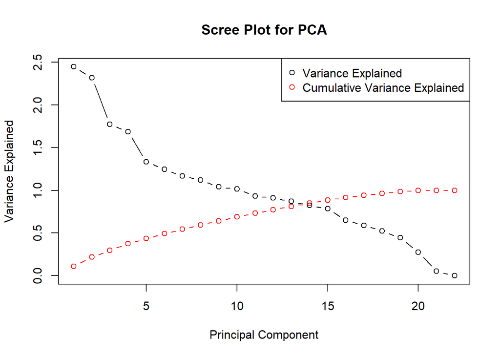

```r
plot(1:length(pca_result$sdev), pca_result$sdev^2,
     type = "b",
     xlab = "Principal Component",
     ylab = "Variance Explained",
     main = "Scree Plot for PCA")


cumulative_variance <- cumsum(pca_result$sdev^2) / sum(pca_result$sdev^2)
lines(1:length(pca_result$sdev), cumulative_variance, type = "b", col = "red")

legend("topright", legend = c("Variance Explained", "Cumulative Variance Explained"),
       col = c("black", "red"), pch = 1)
```

The point of intersection indicates the number of principal components where adding additional components does not contribute significantly to explaining more variance in the data. This point is often used as a guideline for selecting the number of principal components to retain in the analysis.

**Getting the components which contribute to 80 percent of the cumulative variance**

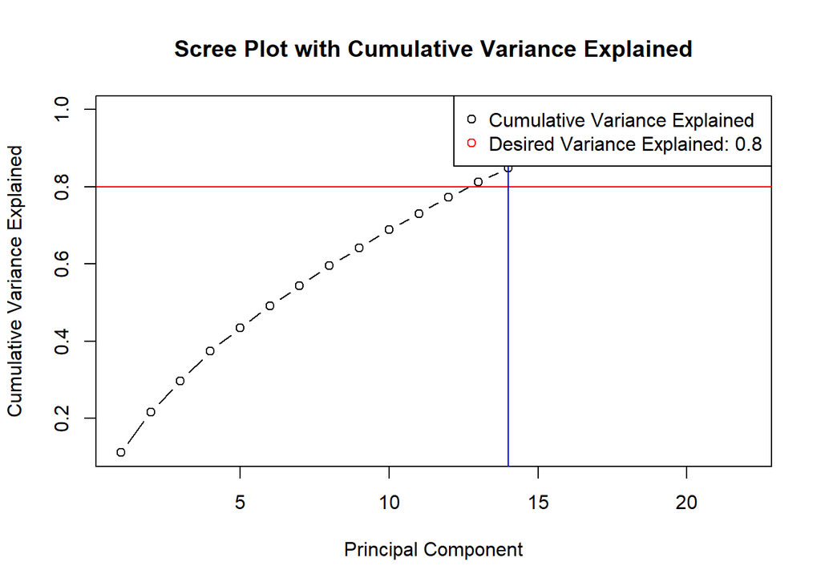

```r
variance_explained <- pca_result$sdev^2 / sum(pca_result$sdev^2)

cumulative_variance_explained <- cumsum(variance_explained)

desired_variance_explained <- 0.8
num_components <- which.max(cumulative_variance_explained >= desired_variance_explained) + 1

plot(1:length(pca_result$sdev), cumulative_variance_explained,
     type = "b",
     xlab = "Principal Component",
     ylab = "Cumulative Variance Explained",
     main = "Scree Plot with Cumulative Variance Explained")

abline(h = desired_variance_explained, col = "red")

abline(v = num_components, col = "blue")

legend("topright", legend = c("Cumulative Variance Explained", paste("Desired Variance Explained:", desired_variance_explained)),
       col = c("black", "red"), pch = 1)
```

```r
cat("Number of principal components selected:", num_components)
```

```
## Number of principal components selected: 14
```

When performing dimensionality reduction with PCA, it’s often desirable to strike a balance between reducing the dimensionality of the data while still retaining a significant amount of information. By setting a desired variance explained of 0.8, we aim to retain a sufficient amount of variability in the data while reducing its dimensionality.

**Again performing principal component analysis on the 14 components selected**

```r
selected_num_components <- num_components
selected_pca_result <- prcomp(encoded_data1, scale. = TRUE, rank. = selected_num_components)

summary(selected_pca_result)
```

```
## Importance of first k=14 (out of 22) components:
##                           PC1    PC2     PC3     PC4     PC5     PC6     PC7
## Standard deviation     1.5643 1.5219 1.33168 1.29883 1.15485 1.11579 1.07996
## Proportion of Variance 0.1112 0.1053 0.08061 0.07668 0.06062 0.05659 0.05301
## Cumulative Proportion  0.1112 0.2165 0.29711 0.37379 0.43441 0.49100 0.54401
##                            PC8     PC9    PC10    PC11    PC12    PC13    PC14
## Standard deviation     1.05844 1.01993 1.00797 0.96604 0.95422 0.93312 0.90679
## Proportion of Variance 0.05092 0.04728 0.04618 0.04242 0.04139 0.03958 0.03738
## Cumulative Proportion  0.59494 0.64222 0.68840 0.73082 0.77221 0.81179 0.84916
```

- The first principal component (PC1) has the largest standard deviation and explains the highest proportion of variance (11.12%). It captures the most significant patterns of variability present in the data.
- Subsequent principal components contribute progressively less to the total variance, as indicated by their decreasing proportions of variance.
- The cumulative proportion of variance explained increases with each additional principal component, indicating that including more components provides a more comprehensive account of the data’s variability.
- In this case, the first 14 principal components (out of 22) collectively explain approximately 84.916% of the total variance in the dataset. This suggests that these 14 components capture the most essential patterns and structures within the data.

**Extract the loadings from the PCA results and plot a graph based on that**

```r
loadings <- selected_pca_result$rotation

print("Loadings Matrix:")
```

```
## [1] "Loadings Matrix:"
```

```r
print(loadings)
```

```
##                                     PC1         PC2          PC3         PC4
## Age                          0.24734815 -0.38206062  0.107730179  0.28910565
## HoursOfSleep                 0.02466060  0.06732267 -0.052977382  0.21900847
## QualityOfSleep               0.20945391  0.34200644 -0.134861034  0.32359531
## NapsInAweek                  0.06138031 -0.07176951 -0.190526162  0.05324483
## PhysicalActivityLevel        0.19535499  0.22269848 -0.013093526  0.10323367
## StressLevel                 -0.20354671 -0.27619999  0.006845844 -0.03720429
## DailySteps                   0.11425954 -0.13648087 -0.094330289 -0.01131356
## HoursOfECDevicesBeforeSleep  0.05776648 -0.14564533  0.072682474 -0.08978998
## HeadacheFrequency           -0.22585033 -0.27221733 -0.152651228 -0.05496949
## BreakfastSkip                0.10431883  0.08045272 -0.212371838  0.03237400
## DinnerTime                  -0.02725865 -0.27914254  0.092439207 -0.13889009
## SleeplessNightsInAWeek      -0.13875301 -0.35592318  0.099413076 -0.33061417
## GenderFemale                -0.51080407 -0.03436274 -0.224034757  0.34781515
## GenderMale                   0.51080407  0.03436274  0.224034757 -0.34781515
## BranchChemIC                 0.10643119 -0.13211421 -0.139429896  0.04441255
## BranchComp                  -0.15020436  0.11917462  0.262667570  0.06354566
## BranchET                     0.02370255 -0.14824748  0.163164978  0.04201600
## BranchIT                    -0.08289176  0.10731535 -0.081005206 -0.27056217
## BranchMech                   0.16439584 -0.13866198 -0.183060436  0.13890075
## YearFirstYear               -0.06813287  0.18923610 -0.484025095 -0.43045524
## YearSecondYear              -0.21673189  0.18235876  0.567292067  0.09723000
## YearThirdYear                0.26626080 -0.34738486 -0.135107453  0.26652855
##                                     PC5         PC6           PC7         PC8
## Age                          0.03291817  0.06411492  0.1112234453 -0.10898062
## HoursOfSleep                -0.30878547 -0.24127064  0.0008378133 -0.05861675
## QualityOfSleep              -0.05029310 -0.01601913  0.1132635494 -0.07661857
## NapsInAweek                 -0.18905326 -0.19224724  0.2637795374  0.30815044
## PhysicalActivityLevel        0.14533932 -0.14578141 -0.1352677995 -0.04427583
## StressLevel                 -0.22378350  0.01459463  0.0230356526  0.20575241
## DailySteps                   0.05265114  0.07468504  0.0114448708 -0.45810399
## HoursOfECDevicesBeforeSleep -0.04402659  0.05834574  0.4012446226  0.20814995
## HeadacheFrequency           -0.19491942  0.09762069  0.1769629889  0.22679294
## BreakfastSkip               -0.34318162  0.26913358  0.0401389232  0.01085440
## DinnerTime                   0.25107579 -0.18988441 -0.0438454885 -0.36176907
## SleeplessNightsInAWeek       0.07742706 -0.02375098 -0.0500877232 -0.09018260
## GenderFemale                 0.08478570 -0.03432526 -0.0293117047 -0.12208820
## GenderMale                  -0.08478570  0.03432526  0.0293117047  0.12208820
## BranchChemIC                -0.22920107  0.50085908 -0.0932882195 -0.29421644
## BranchComp                   0.31945030  0.44768049 -0.0664397220  0.31885181
```

[output cut: 37 more lines]

```
## HoursOfECDevicesBeforeSleep  0.0841647236  0.226332078
## HeadacheFrequency           -0.0395105516 -0.083504796
## BreakfastSkip               -0.6937205757  0.255675656
## DinnerTime                  -0.4834311238 -0.009122098
## SleeplessNightsInAWeek       0.0241951025  0.183116294
## GenderFemale                 0.0342119074  0.108772376
## GenderMale                  -0.0342119074 -0.108772376
## BranchChemIC                 0.1993957552 -0.072475221
## BranchComp                  -0.1356392442  0.080452512
## BranchET                    -0.0670609226  0.161006589
## BranchIT                     0.2125021286 -0.083034832
## BranchMech                  -0.1747034538 -0.138847112
## YearFirstYear               -0.0684208928 -0.036277310
## YearSecondYear              -0.0839911941  0.090750420
## YearThirdYear                0.1891647983 -0.091968495
```

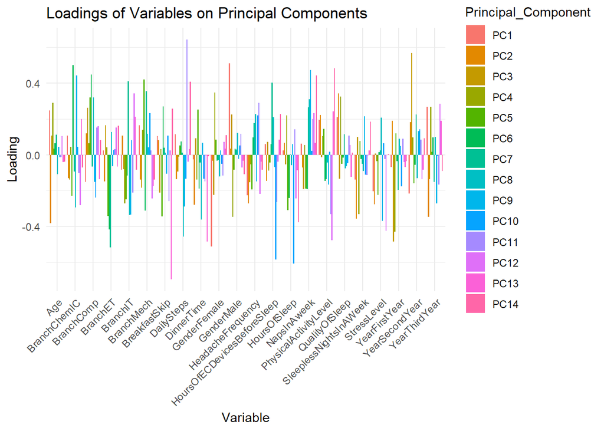

```r
library(ggplot2)

loadings_df <- as.data.frame(loadings)
loadings_df$variable <- rownames(loadings_df)

library(reshape2)
loadings_melted <- melt(loadings_df, id.vars = "variable", variable.name = "Principal_Component", value.name = "Loading")

ggplot(loadings_melted, aes(x = variable, y = Loading, fill = Principal_Component)) +
  geom_bar(stat = "identity", position = "dodge") +
  labs(title = "Loadings of Variables on Principal Components",
       x = "Variable",
       y = "Loading") +
  theme_minimal() +
  theme(axis.text.x = element_text(angle = 45, hjust = 1))
```

The loadings matrix represents the correlations between the original variables and the principal components (PCs) obtained from a principal component analysis (PCA). Each column in the loadings matrix corresponds to a principal component, and each row corresponds to an original variable. The values in the matrix indicate the strength and direction of the relationship between each variable and each principal component.

**Print the loadings matrix and also the loading values for the principal components**

```r
loadings <- selected_pca_result$rotation

print("Loadings Matrix:")
```

```
## [1] "Loadings Matrix:"
```

```r
print(loadings)
```

```
##                                     PC1         PC2          PC3         PC4
## Age                          0.24734815 -0.38206062  0.107730179  0.28910565
## HoursOfSleep                 0.02466060  0.06732267 -0.052977382  0.21900847
## QualityOfSleep               0.20945391  0.34200644 -0.134861034  0.32359531
## NapsInAweek                  0.06138031 -0.07176951 -0.190526162  0.05324483
## PhysicalActivityLevel        0.19535499  0.22269848 -0.013093526  0.10323367
## StressLevel                 -0.20354671 -0.27619999  0.006845844 -0.03720429
## DailySteps                   0.11425954 -0.13648087 -0.094330289 -0.01131356
## HoursOfECDevicesBeforeSleep  0.05776648 -0.14564533  0.072682474 -0.08978998
## HeadacheFrequency           -0.22585033 -0.27221733 -0.152651228 -0.05496949
## BreakfastSkip                0.10431883  0.08045272 -0.212371838  0.03237400
## DinnerTime                  -0.02725865 -0.27914254  0.092439207 -0.13889009
## SleeplessNightsInAWeek      -0.13875301 -0.35592318  0.099413076 -0.33061417
## GenderFemale                -0.51080407 -0.03436274 -0.224034757  0.34781515
## GenderMale                   0.51080407  0.03436274  0.224034757 -0.34781515
## BranchChemIC                 0.10643119 -0.13211421 -0.139429896  0.04441255
## BranchComp                  -0.15020436  0.11917462  0.262667570  0.06354566
## BranchET                     0.02370255 -0.14824748  0.163164978  0.04201600
## BranchIT                    -0.08289176  0.10731535 -0.081005206 -0.27056217
## BranchMech                   0.16439584 -0.13866198 -0.183060436  0.13890075
## YearFirstYear               -0.06813287  0.18923610 -0.484025095 -0.43045524
## YearSecondYear              -0.21673189  0.18235876  0.567292067  0.09723000
## YearThirdYear                0.26626080 -0.34738486 -0.135107453  0.26652855
##                                     PC5         PC6           PC7         PC8
## Age                          0.03291817  0.06411492  0.1112234453 -0.10898062
## HoursOfSleep                -0.30878547 -0.24127064  0.0008378133 -0.05861675
## QualityOfSleep              -0.05029310 -0.01601913  0.1132635494 -0.07661857
## NapsInAweek                 -0.18905326 -0.19224724  0.2637795374  0.30815044
## PhysicalActivityLevel        0.14533932 -0.14578141 -0.1352677995 -0.04427583
## StressLevel                 -0.22378350  0.01459463  0.0230356526  0.20575241
## DailySteps                   0.05265114  0.07468504  0.0114448708 -0.45810399
## HoursOfECDevicesBeforeSleep -0.04402659  0.05834574  0.4012446226  0.20814995
## HeadacheFrequency           -0.19491942  0.09762069  0.1769629889  0.22679294
## BreakfastSkip               -0.34318162  0.26913358  0.0401389232  0.01085440
## DinnerTime                   0.25107579 -0.18988441 -0.0438454885 -0.36176907
## SleeplessNightsInAWeek       0.07742706 -0.02375098 -0.0500877232 -0.09018260
## GenderFemale                 0.08478570 -0.03432526 -0.0293117047 -0.12208820
## GenderMale                  -0.08478570  0.03432526  0.0293117047  0.12208820
## BranchChemIC                -0.22920107  0.50085908 -0.0932882195 -0.29421644
## BranchComp                   0.31945030  0.44768049 -0.0664397220  0.31885181
```

[output cut: 37 more lines]

```
## HoursOfECDevicesBeforeSleep  0.0841647236  0.226332078
## HeadacheFrequency           -0.0395105516 -0.083504796
## BreakfastSkip               -0.6937205757  0.255675656
## DinnerTime                  -0.4834311238 -0.009122098
## SleeplessNightsInAWeek       0.0241951025  0.183116294
## GenderFemale                 0.0342119074  0.108772376
## GenderMale                  -0.0342119074 -0.108772376
## BranchChemIC                 0.1993957552 -0.072475221
## BranchComp                  -0.1356392442  0.080452512
## BranchET                    -0.0670609226  0.161006589
## BranchIT                     0.2125021286 -0.083034832
## BranchMech                  -0.1747034538 -0.138847112
## YearFirstYear               -0.0684208928 -0.036277310
## YearSecondYear              -0.0839911941  0.090750420
## YearThirdYear                0.1891647983 -0.091968495
```

```r
for (i in 1:ncol(loadings)) {
  cat("Principal Component", i, ":\n")

  sorted_loadings <- sort(abs(loadings[, i]), decreasing = TRUE)

  for (j in 1:length(sorted_loadings)) {
    var_name <- rownames(loadings)[which(abs(loadings[, i]) == sorted_loadings[j])]
    cat(var_name, ": ", loadings[var_name, i], "\n")
  }
  cat("\n")
}
```

```
## Principal Component 1 :
## GenderMale :  0.5108041
## GenderFemale :  -0.5108041
## YearThirdYear :  0.2662608
## Age :  0.2473482
## HeadacheFrequency :  -0.2258503
## YearSecondYear :  -0.2167319
## QualityOfSleep :  0.2094539
## StressLevel :  -0.2035467
## PhysicalActivityLevel :  0.195355
## BranchMech :  0.1643958
## BranchComp :  -0.1502044
## SleeplessNightsInAWeek :  -0.138753
## DailySteps :  0.1142595
## BranchChemIC :  0.1064312
## BreakfastSkip :  0.1043188
## BranchIT :  -0.08289176
## YearFirstYear :  -0.06813287
## NapsInAweek :  0.06138031
## HoursOfECDevicesBeforeSleep :  0.05776648
## DinnerTime :  -0.02725865
## HoursOfSleep :  0.0246606
## BranchET :  0.02370255
##
## Principal Component 2 :
## Age :  -0.3820606
## SleeplessNightsInAWeek :  -0.3559232
## YearThirdYear :  -0.3473849
## QualityOfSleep :  0.3420064
## DinnerTime :  -0.2791425
## StressLevel :  -0.2762
## HeadacheFrequency :  -0.2722173
## PhysicalActivityLevel :  0.2226985
## YearFirstYear :  0.1892361
## YearSecondYear :  0.1823588
## BranchET :  -0.1482475
## HoursOfECDevicesBeforeSleep :  -0.1456453
## BranchMech :  -0.138662
## DailySteps :  -0.1364809
## BranchChemIC :  -0.1321142
```

[output cut: 280 more lines]

```
## BranchET :  0.1610066
## BranchMech :  -0.1388471
## GenderMale :  -0.1087724
## GenderFemale :  0.1087724
## YearThirdYear :  -0.0919685
## YearSecondYear :  0.09075042
## HeadacheFrequency :  -0.0835048
## BranchIT :  -0.08303483
## BranchComp :  0.08045251
## BranchChemIC :  -0.07247522
## Age :  -0.03761194
## YearFirstYear :  -0.03627731
## QualityOfSleep :  0.01250581
## DinnerTime :  -0.009122098
## StressLevel :  0.00347839
```

Let’s take PC1 as an example:

- Variables with high positive loadings on PC1 include GenderMale, Age, QualityOfSleep, and PhysicalActivityLevel. This suggests that individuals with higher age, better sleep quality, and higher physical activity levels tend to have higher values on PC1.
- Conversely, variables with high negative loadings on PC1 include GenderFemale and HeadacheFrequency. This suggests that individuals who are female or experience more headaches tend to have lower values on PC1.

**Plot a biplot to showcase the results of the principal component analysis**

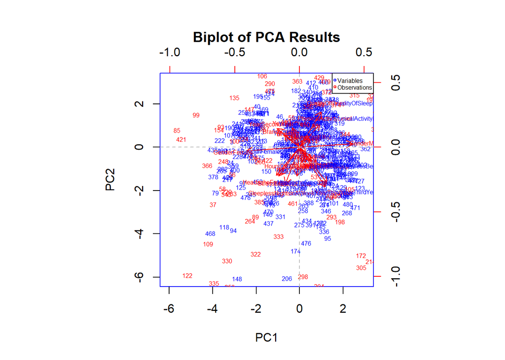

```r
scores <- as.data.frame(selected_pca_result$x)

biplot(selected_pca_result, scale = 0, col = c("blue", "red"), cex = 0.5, main = "Biplot of PCA Results")

text(selected_pca_result$rotation, labels = colnames(encoded_data1), col = "blue", cex = 0.5, pos = 4)

text(scores[, 1], scores[, 2], labels = rownames(scores), col = "red", cex = 0.5, pos = 4)

abline(h = 0, v = 0, col = "gray", lty = 2)

legend("topright", legend = c("Variables", "Observations"), col = c("blue", "red"), pch = 1, cex = 0.5)
```

Overall, the biplot provides a visual representation of the relationships between observations and variables in the reduced-dimensional space defined by the principal components. It helps to visualize patterns, clusters, and correlations in the data.

**Performing hypothesis testing on all the columns to identify which variables are affecting sleep quality and which do not seem to affect the quality of sleep**

1. Hypothesis: Individuals who engage in higher levels of physical activity have better sleep quality.

```r
library(dplyr)
```

```r
library(ggplot2)

data_subset <- encoded_data1[, c("PhysicalActivityLevel", "QualityOfSleep")]

model <- lm(QualityOfSleep ~ PhysicalActivityLevel, data = data_subset)

summary(model)
```

```
##
## Call:
## lm(formula = QualityOfSleep ~ PhysicalActivityLevel, data = data_subset)
##
## Residuals:
##     Min      1Q  Median      3Q     Max
## -6.4448 -1.2440  0.3561  1.4562  4.3573
##
## Coefficients:
##                       Estimate Std. Error t value Pr(>|t|)
## (Intercept)            5.44245    0.27159  20.039  < 2e-16 ***
## PhysicalActivityLevel  0.20024    0.04159   4.814 1.98e-06 ***
## ---
## Signif. codes:  0 '***' 0.001 '**' 0.01 '*' 0.05 '.' 0.1 ' ' 1
##
## Residual standard error: 2.171 on 481 degrees of freedom
## Multiple R-squared:  0.04597,    Adjusted R-squared:  0.04399
## F-statistic: 23.18 on 1 and 481 DF,  p-value: 1.981e-06
```

**Correlation between physical activity level and Quality Of Sleep**

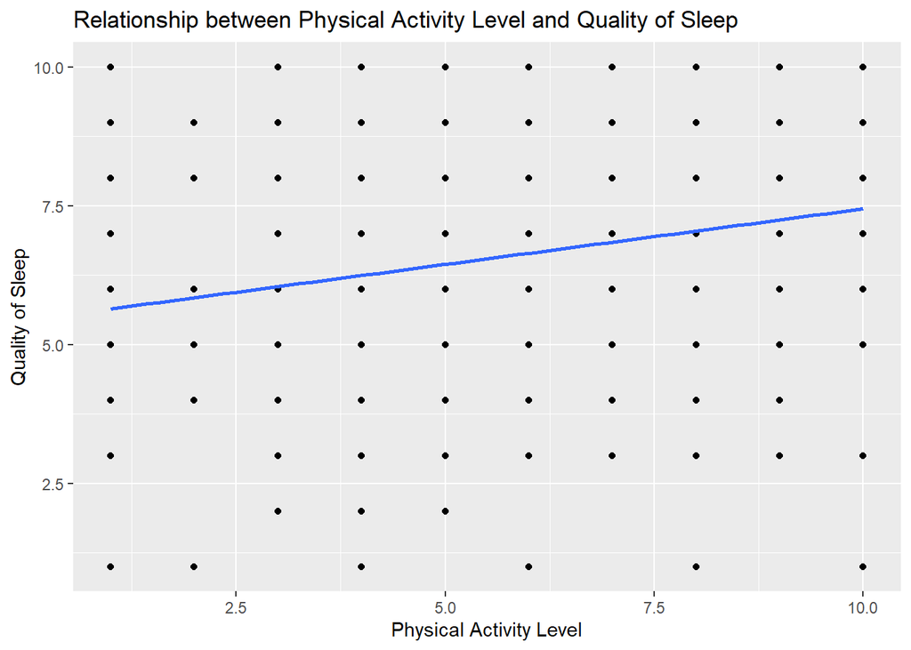

```r
ggplot(data_subset, aes(x = PhysicalActivityLevel, y = QualityOfSleep)) +
  geom_point() +
  geom_smooth(method = "lm", se = FALSE) +
  labs(x = "Physical Activity Level", y = "Quality of Sleep") +
  ggtitle("Relationship between Physical Activity Level and Quality of Sleep")
```

Null Hypothesis (H0): There is no significant relationship between physical activity level and sleep quality.

In this case, the p-value for “PhysicalActivityLevel” is very small (1.98e-06), indicating that it is highly unlikely to observe the estimated coefficient value if the true coefficient were zero (i.e., if there were no relationship between physical activity level and sleep quality). Therefore, we reject the null hypothesis.

In simpler terms, the statistical evidence suggests that there is a significant relationship between physical activity level and sleep quality.

2. Hypothesis: Skipping breakfast is associated with sleepless nights.

```r
data_subset <- encoded_data1[, c("BreakfastSkip", "QualityOfSleep")]

model <- lm(QualityOfSleep ~ BreakfastSkip, data = data_subset)

summary(model)
```

```
##
## Call:
## lm(formula = QualityOfSleep ~ BreakfastSkip, data = data_subset)
##
## Residuals:
##     Min      1Q  Median      3Q     Max
## -6.1192 -1.1804  0.3502  1.5849  3.8196
##
## Coefficients:
##               Estimate Std. Error t value Pr(>|t|)
## (Intercept)    5.94565    0.22512  26.411  < 2e-16 ***
## BreakfastSkip  0.23470    0.06625   3.543 0.000435 ***
## ---
## Signif. codes:  0 '***' 0.001 '**' 0.01 '*' 0.05 '.' 0.1 ' ' 1
##
## Residual standard error: 2.194 on 481 degrees of freedom
## Multiple R-squared:  0.02543,    Adjusted R-squared:  0.0234
## F-statistic: 12.55 on 1 and 481 DF,  p-value: 0.0004346
```

**Correlation between Breakfast Skip and Quality Of Sleep**

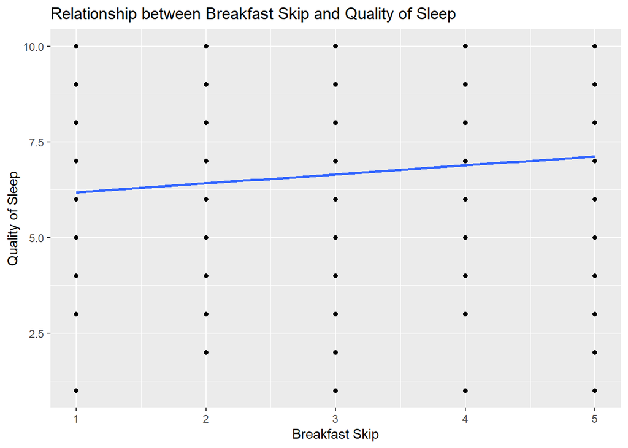

```r
ggplot(data_subset, aes(x = BreakfastSkip, y = QualityOfSleep)) +
  geom_point() +
  geom_smooth(method = "lm", se = FALSE) +
  labs(x = "Breakfast Skip", y = "Quality of Sleep") +
  ggtitle("Relationship between Breakfast Skip and Quality of Sleep")
```

In this case, the p-value for “BreakfastSkip” is very small (0.0004346), indicating that it is highly unlikely to observe the estimated coefficient value if the true coefficient were zero (i.e., if there were no relationship between skipping breakfast and sleep quality). Therefore, we reject the null hypothesis.

In simpler terms, the statistical evidence suggests that there is a significant relationship between skipping breakfast and sleep quality.

3. Hypothesis: Age is associated with sleep quality.

```r
data_subset <- encoded_data1[, c("Age", "QualityOfSleep")]

model <- lm(QualityOfSleep ~ Age, data = data_subset)

summary(model)
```

```
##
## Call:
## lm(formula = QualityOfSleep ~ Age, data = data_subset)
##
## Residuals:
##     Min      1Q  Median      3Q     Max
## -5.8606 -1.4953  0.3829  1.3829  3.7482
##
## Coefficients:
##             Estimate Std. Error t value Pr(>|t|)
## (Intercept)  9.05231    1.67788   5.395 1.08e-07 ***
## Age         -0.12176    0.08526  -1.428    0.154
## ---
## Signif. codes:  0 '***' 0.001 '**' 0.01 '*' 0.05 '.' 0.1 ' ' 1
##
## Residual standard error: 2.218 on 481 degrees of freedom
## Multiple R-squared:  0.004222,   Adjusted R-squared:  0.002152
## F-statistic: 2.039 on 1 and 481 DF,  p-value: 0.1539
```

**Correlation between Age and Quality Of Sleep**

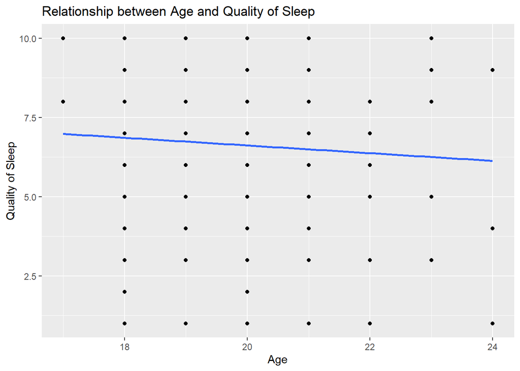

```r
ggplot(data_subset, aes(x = Age, y = QualityOfSleep)) +
  geom_point() +
  geom_smooth(method = "lm", se = FALSE) +
  labs(x = "Age", y = "Quality of Sleep") +
  ggtitle("Relationship between Age and Quality of Sleep")
```

Null Hypothesis (H0): There is no significant relationship between age and sleep quality.

In this case, the p-value for “Age” is quite large (0.1539), indicating that it is highly likely to observe the estimated coefficient value if the true coefficient were zero (i.e., if there were no relationship between age and sleep quality). Therefore, we accept the null hypothesis.

In simpler terms, the statistical evidence suggests that there is no significant relationship between age and sleep quality.

4. Hypothesis: There is a difference in sleep quality between different genders.

```r
library(dplyr)

data_subset <- encoded_data1[, c("QualityOfSleep", "GenderMale", "GenderFemale")]

t_test_result <- t.test(QualityOfSleep ~ GenderMale, data = data_subset)

print(t_test_result)
```

```
##
##  Welch Two Sample t-test
##
## data:  QualityOfSleep by GenderMale
## t = -1.3998, df = 201.94, p-value = 0.1631
## alternative hypothesis: true difference in means between group 0 and group 1 is not equal to 0
## 95 percent confidence interval:
##  -0.7945322  0.1347906
## sample estimates:
## mean in group 0 mean in group 1
##        6.413223        6.743094
```

In simpler terms, the statistical evidence suggests that there is no significant relationship between gender and sleep quality.

5. Hypothesis: There is a difference in sleep quality between different branches of individuals.

```r
data_subset <- encoded_data1[, c("QualityOfSleep", "BranchChemIC", "BranchIT", "BranchET", "BranchComp", "BranchMech")]

anova_result <- aov(QualityOfSleep ~ BranchChemIC + BranchIT + BranchET + BranchComp + BranchMech, data = data_subset)

print(summary(anova_result))
```

```
##               Df Sum Sq Mean Sq F value Pr(>F)
## BranchChemIC   1    0.2   0.158   0.032 0.8577
## BranchIT       1    0.1   0.051   0.010 0.9188
## BranchET       1   29.0  28.987   5.913 0.0154 *
## BranchComp     1    8.2   8.198   1.672 0.1966
## BranchMech     1    0.4   0.389   0.079 0.7784
## Residuals    477 2338.5   4.903
## ---
## Signif. codes:  0 '***' 0.001 '**' 0.01 '*' 0.05 '.' 0.1 ' ' 1
```

Null Hypothesis (H0): There is no significant difference in sleep quality between different branches.

-BranchENTC has a p-value of 0.0154, which is less than 0.05. Therefore, you would reject the null hypothesis for this branch and conclude that there is evidence of a significant difference in the mean response variable among the branches.In simpler terms, the statistical evidence suggests that there is a significant relationship between being in BranchENTC and sleep quality.

-For the other branches (ChemIC, IT, Comp, Mech), their respective p-values are all greater than 0.05. Therefore, you would fail to reject the null hypothesis for these branches, indicating that there is insufficient evidence to conclude that there is a significant difference in the mean response variable among these branches.In simpler terms, the statistical evidence suggests that there is no significant relationship between being in a branch other than BranchENTC and sleep quality.

6. Hypothesis: There is a difference in sleep quality between individuals of different years of engineering.

```r
data_subset <- encoded_data1[, c("QualityOfSleep", "YearFirstYear", "YearSecondYear", "YearThirdYear")]

anova_result <- aov(QualityOfSleep ~ YearFirstYear + YearSecondYear + YearThirdYear, data = data_subset)

print(summary(anova_result))
```

```
##                 Df Sum Sq Mean Sq F value Pr(>F)
## YearFirstYear    1    0.5   0.527   0.106  0.744
## YearSecondYear   1    0.7   0.707   0.143  0.706
## YearThirdYear    1    0.2   0.171   0.035  0.853
## Residuals      479 2374.9   4.958
```

Null Hypothesis (H0): There is no significant difference in sleep quality between different years of engineering.

For all year categories (FirstYear, SecondYear, ThirdYear), their respective p-values are all greater than 0.05. Therefore, you would fail to reject the null hypothesis for all year categories, indicating that there is insufficient evidence to conclude that there is a significant difference in the mean response variable among the different year categories.

In simpler words, being in specific year of engineering does not have a significant impact on sleep quality.

7. Hypothesis: Individuals who nap more frequently have better quality of sleep.

```r
data_subset <- encoded_data1[, c("NapsInAweek", "QualityOfSleep")]

model <- lm(QualityOfSleep ~ NapsInAweek, data = data_subset)

summary(model)
```

```
##
## Call:
## lm(formula = QualityOfSleep ~ NapsInAweek, data = data_subset)
##
## Residuals:
##     Min      1Q  Median      3Q     Max
## -5.9042 -1.5253  0.3484  1.4747  3.4747
##
## Coefficients:
##             Estimate Std. Error t value Pr(>|t|)
## (Intercept)   6.3990     0.2378  26.912   <2e-16 ***
## NapsInAweek   0.1263     0.1040   1.215    0.225
## ---
## Signif. codes:  0 '***' 0.001 '**' 0.01 '*' 0.05 '.' 0.1 ' ' 1
##
## Residual standard error: 2.219 on 481 degrees of freedom
## Multiple R-squared:  0.003059,   Adjusted R-squared:  0.0009859
## F-statistic: 1.476 on 1 and 481 DF,  p-value: 0.225
```

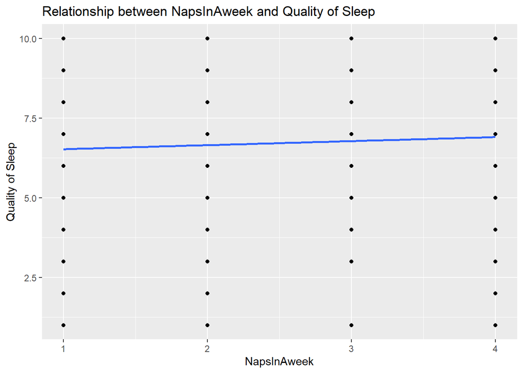

```r
ggplot(data_subset, aes(x = NapsInAweek, y = QualityOfSleep)) +
  geom_point() +
  geom_smooth(method = "lm", se = FALSE) +
  labs(x = "NapsInAweek", y = "Quality of Sleep") +
  ggtitle("Relationship between NapsInAweek and Quality of Sleep")
```

Null Hypothesis (H0): There is no significant relationship between frequency of naps and sleep quality.

In this case, the p-value for “NapsInAWeek” is quite large (0.225), indicating that it is highly likely to observe the estimated coefficient value if the true coefficient were zero (i.e., if there were no relationship between frequency of naps and sleep quality). Therefore, we accept the null hypothesis.

In simpler terms, the statistical evidence suggests that there is no significant relationship between frequency of naps and sleep quality.

8. Hypothesis The time individuals spend on electronic devices before sleep affects their sleep quality.

```r
data_subset <- encoded_data1[, c("HoursOfECDevicesBeforeSleep", "QualityOfSleep")]

model <- lm(QualityOfSleep ~ HoursOfECDevicesBeforeSleep, data = data_subset)


summary(model)
```

```
##
## Call:
## lm(formula = QualityOfSleep ~ HoursOfECDevicesBeforeSleep, data = data_subset)
##
## Residuals:
##     Min      1Q  Median      3Q     Max
## -5.8588 -1.4730  0.2698  1.5270  3.6556
##
## Coefficients:
##                             Estimate Std. Error t value Pr(>|t|)
## (Intercept)                  6.98741    0.21150  33.037   <2e-16 ***
## HoursOfECDevicesBeforeSleep -0.12860    0.07313  -1.759   0.0793 .
## ---
## Signif. codes:  0 '***' 0.001 '**' 0.01 '*' 0.05 '.' 0.1 ' ' 1
##
## Residual standard error: 2.216 on 481 degrees of freedom
## Multiple R-squared:  0.006388,   Adjusted R-squared:  0.004322
## F-statistic: 3.092 on 1 and 481 DF,  p-value: 0.0793
```

**Correlation between Hours of EC devices before Sleep**

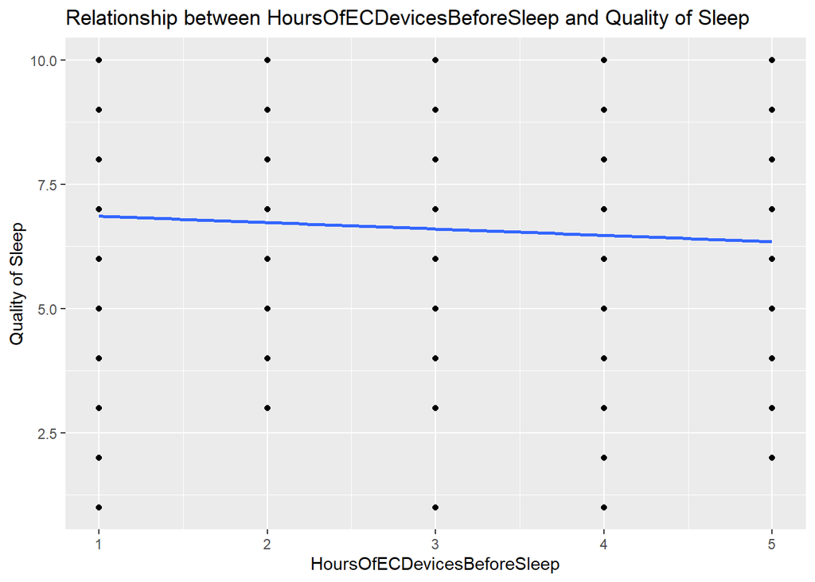

```r
ggplot(data_subset, aes(x = HoursOfECDevicesBeforeSleep, y = QualityOfSleep)) +
  geom_point() +
  geom_smooth(method = "lm", se = FALSE) +
  labs(x = "HoursOfECDevicesBeforeSleep", y = "Quality of Sleep") +
  ggtitle("Relationship between HoursOfECDevicesBeforeSleep and Quality of Sleep")
```

Null Hypothesis (H0): There is no significant relationship between hours spent on electronic devices before sleep and sleep quality.

In this case, the p-value for “HoursOfECDevicesBeforeSleep” is quite large (0.0793), indicating that it is highly likely to observe the estimated coefficient value if the true coefficient were zero (i.e., if there were no relationship between hours spent on electronic devices before sleep and sleep quality). Therefore, we accept the null hypothesis.

In simpler terms, the statistical evidence suggests that there is no significant relationship between hours spent on electronic devices before sleep and sleep quality.

9. Hypothesis: There is a relationship between the number of daily steps and sleep quality.

```r
data_subset <- encoded_data1[, c("DailySteps", "QualityOfSleep")]

model <- lm(QualityOfSleep ~ DailySteps, data = data_subset)

summary(model)
```

```
##
## Call:
## lm(formula = QualityOfSleep ~ DailySteps, data = data_subset)
##
## Residuals:
##    Min     1Q Median     3Q    Max
## -5.771 -1.583  0.379  1.398  3.417
##
## Coefficients:
##             Estimate Std. Error t value Pr(>|t|)
## (Intercept)  6.54581    0.19762  33.124   <2e-16 ***
## DailySteps   0.03762    0.05572   0.675      0.5
## ---
## Signif. codes:  0 '***' 0.001 '**' 0.01 '*' 0.05 '.' 0.1 ' ' 1
##
## Residual standard error: 2.222 on 481 degrees of freedom
## Multiple R-squared:  0.0009468,  Adjusted R-squared:  -0.00113
## F-statistic: 0.4559 on 1 and 481 DF,  p-value: 0.4999
```

**Correlation between Daily Steps and Quality Of Sleep**

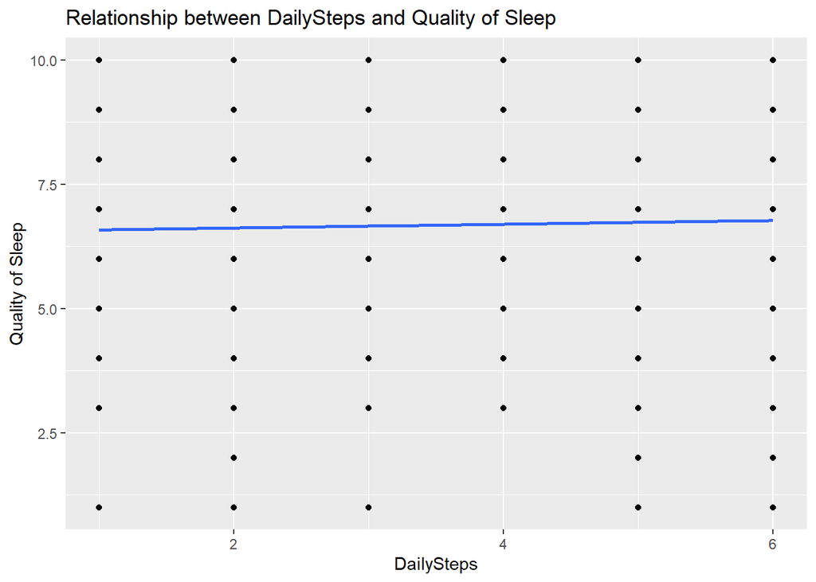

```r
ggplot(data_subset, aes(x = DailySteps, y = QualityOfSleep)) +
  geom_point() +
  geom_smooth(method = "lm", se = FALSE) +
  labs(x = "DailySteps", y = "Quality of Sleep") +
  ggtitle("Relationship between DailySteps and Quality of Sleep")
```

Null Hypothesis (H0): There is no significant relationship between the number of daily steps and sleep quality.

In this case, the p-value for “DailySteps” is quite large (0.4999), indicating that it is highly likely to observe the estimated coefficient value if the true coefficient were zero (i.e., if there were no relationship between number of daily steps and sleep quality). Therefore, we accept the null hypothesis.

In simpler terms, the statistical evidence suggests that there is no significant relationship between number of daily steps and sleep quality.

10. Hypothesis: There is a difference in sleep quality between individuals experiencing different levels of stress.

```r
data_subset <- encoded_data1[, c("StressLevel", "QualityOfSleep")]

model <- lm(QualityOfSleep ~ StressLevel, data = data_subset)

summary(model)
```

```
##
## Call:
## lm(formula = QualityOfSleep ~ StressLevel, data = data_subset)
##
## Residuals:
##     Min      1Q  Median      3Q     Max
## -6.8751 -1.2784  0.2654  1.4935  4.1778
##
## Coefficients:
##             Estimate Std. Error t value Pr(>|t|)
## (Intercept)  8.10325    0.26182  30.950  < 2e-16 ***
## StressLevel -0.22811    0.03841  -5.939 5.51e-09 ***
## ---
## Signif. codes:  0 '***' 0.001 '**' 0.01 '*' 0.05 '.' 0.1 ' ' 1
##
## Residual standard error: 2.145 on 481 degrees of freedom
## Multiple R-squared:  0.06832,    Adjusted R-squared:  0.06638
## F-statistic: 35.27 on 1 and 481 DF,  p-value: 5.506e-09
```

**Correlation of Stress Level and Quality Of Sleep**

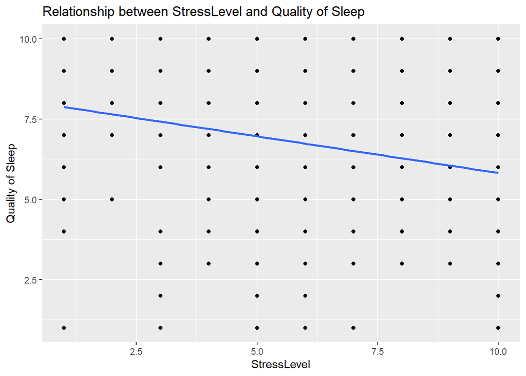

```r
ggplot(data_subset, aes(x = StressLevel, y = QualityOfSleep)) +
  geom_point() +
  geom_smooth(method = "lm", se = FALSE) +
  labs(x = "StressLevel", y = "Quality of Sleep") +
  ggtitle("Relationship between StressLevel and Quality of Sleep")
```

Null Hypothesis (H0): There is no significant difference in sleep quality between individuals experiencing different levels of stress.

In this case, the p-value for “StressLevel” is very small (5.506e-09), indicating that it is highly unlikely to observe the estimated coefficient value if the true coefficient were zero (i.e., if there were no relationship between stress levels and sleep quality). Therefore, we reject the null hypothesis.

In simpler terms, the statistical evidence suggests that there is a significant relationship between stress levels and sleep quality.

11. Hypothesis: There is a relationship between headache frequency and sleep quality.

```r
data_subset <- encoded_data1[, c("HeadacheFrequency", "QualityOfSleep")]

model <- lm(QualityOfSleep ~ HeadacheFrequency, data = data_subset)

summary(model)
```

```
##
## Call:
## lm(formula = QualityOfSleep ~ HeadacheFrequency, data = data_subset)
##
## Residuals:
##     Min      1Q  Median      3Q     Max
## -6.1684 -1.3123  0.5438  1.5438  4.2559
##
## Coefficients:
##                   Estimate Std. Error t value Pr(>|t|)
## (Intercept)        7.52449    0.19792  38.019  < 2e-16 ***
## HeadacheFrequency -0.35608    0.07073  -5.034 6.79e-07 ***
## ---
## Signif. codes:  0 '***' 0.001 '**' 0.01 '*' 0.05 '.' 0.1 ' ' 1
##
## Residual standard error: 2.166 on 481 degrees of freedom
## Multiple R-squared:  0.05006,    Adjusted R-squared:  0.04808
## F-statistic: 25.35 on 1 and 481 DF,  p-value: 6.785e-07
```

**Correlation between Headache Frequency and Quality Of Sleep**

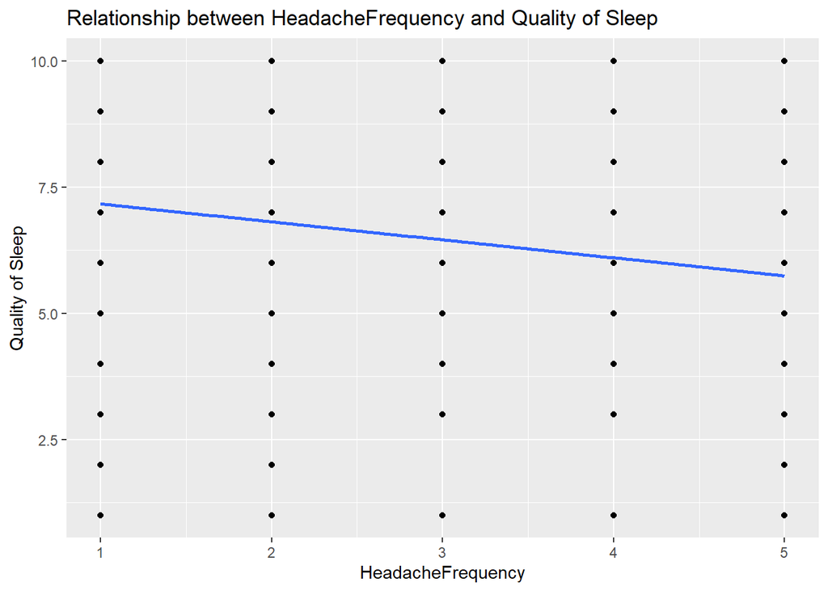

```r
ggplot(data_subset, aes(x = HeadacheFrequency, y = QualityOfSleep)) +
  geom_point() +
  geom_smooth(method = "lm", se = FALSE) +
  labs(x = "HeadacheFrequency", y = "Quality of Sleep") +
  ggtitle("Relationship between HeadacheFrequency and Quality of Sleep")
```

Null Hypothesis (H0): There is no significant relationship between headache frequency and sleep quality.

In this case, the p-value for “HeadacheFrequency” is very small (6.785e-07), indicating that it is highly unlikely to observe the estimated coefficient value if the true coefficient were zero (i.e., if there were no relationship between headache frequency and sleep quality). Therefore, we reject the null hypothesis.

In simpler terms, the statistical evidence suggests that there is a significant relationship between headache frequency and sleep quality.

12. Hypothesis: There is a relationship between the timing of dinner and sleep quality.

```r
data_subset <- encoded_data1[, c("DinnerTime", "QualityOfSleep")]

model <- lm(QualityOfSleep ~ DinnerTime, data = data_subset)

summary(model)
```

```
##
## Call:
## lm(formula = QualityOfSleep ~ DinnerTime, data = data_subset)
##
## Residuals:
##     Min      1Q  Median      3Q     Max
## -5.9789 -1.5128  0.4075  1.4075  4.5668
##
## Coefficients:
##             Estimate Std. Error t value Pr(>|t|)
## (Intercept)  7.36527    0.19027  38.710  < 2e-16 ***
## DinnerTime  -0.38641    0.08901  -4.341 1.73e-05 ***
## ---
## Signif. codes:  0 '***' 0.001 '**' 0.01 '*' 0.05 '.' 0.1 ' ' 1
##
## Residual standard error: 2.18 on 481 degrees of freedom
## Multiple R-squared:  0.0377, Adjusted R-squared:  0.0357
## F-statistic: 18.85 on 1 and 481 DF,  p-value: 1.729e-05
```

**Correlation between Dinner Time and Quality Of Sleep**

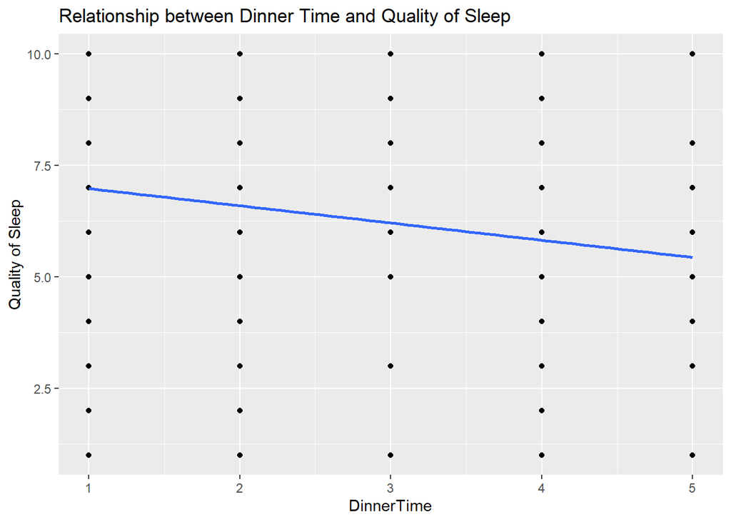

```r
ggplot(data_subset, aes(x = DinnerTime, y = QualityOfSleep)) +
  geom_point() +
  geom_smooth(method = "lm", se = FALSE) +
  labs(x = "DinnerTime", y = "Quality of Sleep") +
  ggtitle("Relationship between Dinner Time and Quality of Sleep")
```

Null Hypothesis (H0): There is no significant relationship between dinner time and sleep quality.

In this case, the p-value for “DinnerTime” is very small (1.729e-05), indicating that it is highly unlikely to observe the estimated coefficient value if the true coefficient were zero (i.e., if there were no relationship between dinner time and sleep quality). Therefore, we reject the null hypothesis.

In simpler terms, the statistical evidence suggests that there is a significant relationship between dinner time and sleep quality.

**Normalizing the columns Hours Of Sleep, Quality Of Sleep, Stress Level and Sleepless Nights In A Week**

```r
library(dplyr)

data_subset <- encoded_data1[, c("HoursOfSleep", "QualityOfSleep", "StressLevel","SleeplessNightsInAWeek")]

normalized_data <- scale(data_subset)

head(normalized_data)
```

```
##   HoursOfSleep QualityOfSleep StressLevel SleeplessNightsInAWeek
## 1   -1.9964964     -1.1981951   1.4444408              1.5029613
## 2   -0.6571801      0.6032936   1.4444408              0.1332815
## 3   -0.6571801     -0.2974508   0.2652888              0.1332815
## 4   -0.6571801      0.1529214   1.4444408             -0.5515585
## 5    0.6821363      1.5040379  -2.0930151             -0.5515585
## 6   -0.6571801      0.6032936   1.4444408             -0.5515585
```

**Performing K-Means Clustering on this normalized data**

```r
if (!is.data.frame(normalized_data)) {
  normalized_data <- as.data.frame(normalized_data)
}

normalized_data <- na.omit(normalized_data)

str(normalized_data)
```

```
## 'data.frame':    483 obs. of  4 variables:
##  $ HoursOfSleep          : num  -1.996 -0.657 -0.657 -0.657 0.682 ...
##  $ QualityOfSleep        : num  -1.198 0.603 -0.297 0.153 1.504 ...
##  $ StressLevel           : num  1.444 1.444 0.265 1.444 -2.093 ...
##  $ SleeplessNightsInAWeek: num  1.503 0.133 0.133 -0.552 -0.552 ...
```

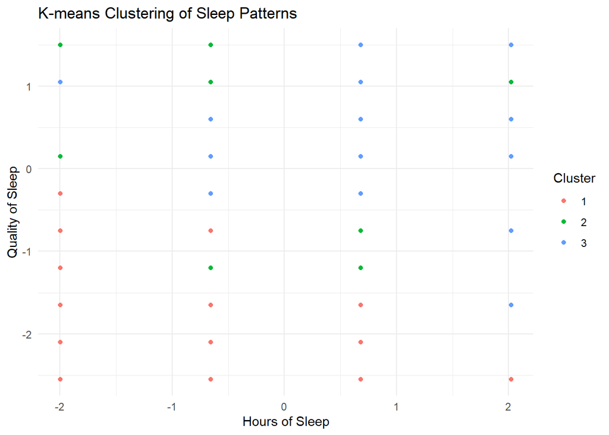

```r
kmeans_model <- kmeans(normalized_data, centers = 3, nstart = 10)

normalized_data$cluster <- as.factor(kmeans_model$cluster)

ggplot(normalized_data, aes(x = HoursOfSleep, y = QualityOfSleep, color = cluster)) +
  geom_point() +
  labs(title = "K-means Clustering of Sleep Patterns",
       x = "Hours of Sleep",
       y = "Quality of Sleep",
       color = "Cluster") +
  theme_minimal()
```

**Plotting the 3d scatterplot for the clusters**

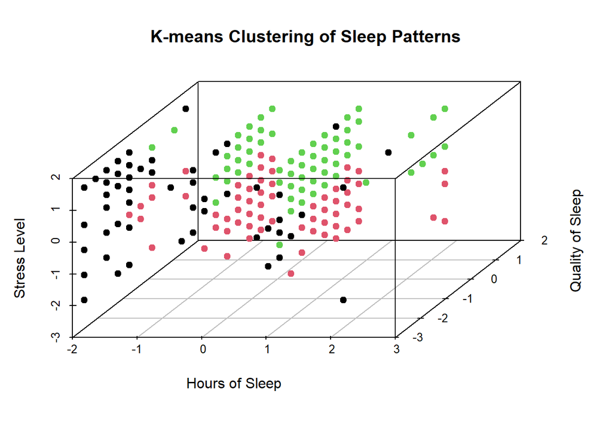

```r
library(scatterplot3d)
normalized_data$cluster <- as.factor(kmeans_model$cluster)

scatterplot3d(normalized_data$HoursOfSleep, normalized_data$QualityOfSleep, normalized_data$StressLevel,
              color = as.numeric(normalized_data$cluster),
              pch = 19,
              main = "K-means Clustering of Sleep Patterns",
              xlab = "Hours of Sleep",
              ylab = "Quality of Sleep",
              zlab = "Stress Level",
              angle = 55)
```

**Plotting the Pair Plots for these normalized columns**

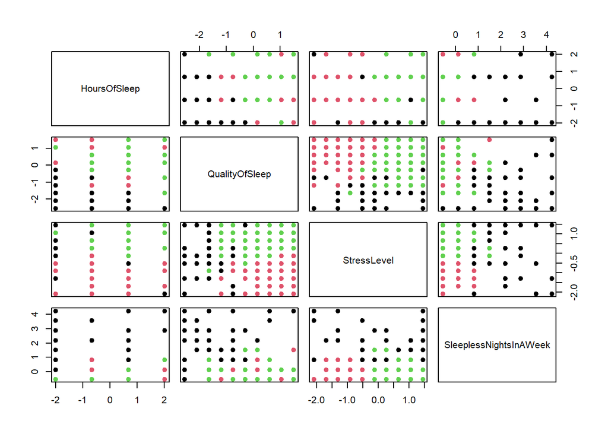

```r
normalized_data$cluster <- as.factor(kmeans_model$cluster)

normalized_subset <- normalized_data[, c("HoursOfSleep", "QualityOfSleep", "StressLevel", "SleeplessNightsInAWeek", "cluster")]

pairs(normalized_subset[, -5], col = normalized_subset$cluster, pch = 19)
```

**Normalizing the columns Breakfast Skip, Quality Of Sleep, Dinner Time, Headache Frequency and Sleepless Nights In A Week**

```r
library(dplyr)

data_subset <- encoded_data1[, c("BreakfastSkip", "QualityOfSleep", "DinnerTime","SleeplessNightsInAWeek","HeadacheFrequency")]

normalized_data <- scale(data_subset)

head(normalized_data)
```

```
##   BreakfastSkip QualityOfSleep DinnerTime SleeplessNightsInAWeek
## 1    -1.3559086     -1.1981951 -0.7385312              1.5029613
## 2    -0.6930505      0.6032936  0.1577265              0.1332815
## 3    -1.3559086     -0.2974508  1.0539842              0.1332815
## 4    -0.6930505      0.1529214  0.1577265             -0.5515585
## 5    -0.0301923      1.5040379  1.0539842             -0.5515585
## 6    -0.6930505      0.6032936 -0.7385312             -0.5515585
##   HeadacheFrequency
## 1         -1.022496
## 2         -1.022496
## 3         -0.305710
## 4         -1.022496
## 5         -0.305710
## 6          0.411076
```

```r
if (!is.data.frame(normalized_data)) {
  normalized_data <- as.data.frame(normalized_data)
}
normalized_data <- na.omit(normalized_data)

str(normalized_data)
```

```
## 'data.frame':    483 obs. of  5 variables:
##  $ BreakfastSkip         : num  -1.3559 -0.6931 -1.3559 -0.6931 -0.0302 ...
##  $ QualityOfSleep        : num  -1.198 0.603 -0.297 0.153 1.504 ...
##  $ DinnerTime            : num  -0.739 0.158 1.054 0.158 1.054 ...
##  $ SleeplessNightsInAWeek: num  1.503 0.133 0.133 -0.552 -0.552 ...
##  $ HeadacheFrequency     : num  -1.022 -1.022 -0.306 -1.022 -0.306 ...
```